# beatochess

Beat Neuenschwander, email: neuenschwander.beat@gmail.com

2024-07-01

# Introduction

The **beatochess** homepage is a repository of ongoing work. It contains

- revisions (corrections, versions, modification) of and comments on studies by other authors
- a collection of my own studies

# Updates since last version

Not appicable (since this is the first version)

# Legend

- (c): correction; i.e. original study was unsound.
- (m): modification; i.e. original study was sound, the improvement has another motivation.
- (s): corrected solution (without changing the position).
- (v): version (perhaps a correction or a modification).
- BN: Beat Neuenschwander
- AN: 100% anticipation: the whole study was published earlier by someone else.
- CR: colours reversed (the original stipulation was: Black to win/draw).
- MC: too many composers to fit the “White” field. All names given as text before the first move.
- PH: posthumously published.
- SSZ: Schweizerische Schachzeitung
- TE: theoretical ending (i.e. probably not an endgame study).
- TT: theme tourney.
- TW: twin study (also triplicates, quadruplicates, etc).
- U1: second solution (at move 1).
- U2: cook; extra solution after move 1.
- U3: incorrect; White is unable to fulfil the stipulation (in a win study Black draws or wins; in a draw study White loses).
- U4: “super-cook”. White can even win in a study with a draw stipulation.
- U5: illegal initial position.

# Links

https://www.arves.org

https://www.github.com/beatochess

# Revised studies (corrections, etc.)

Note: in my revisions, the author will be given as “Original Author BN”. This is a small deviation to the **HHdbVI** database by Harold van der Heijden, where the author of the revision is only mentioned in the solution.

## Studies by Zakhodyakin

In this section, you find a few new cooks, comments, and revisions.

Zakhodyakin in HHdbVI

| author | res.gbr.wkbk | comments | year | source |
| --- | --- | --- | --- | --- |
| Zakhodyakin, G | =0010.22h4h6 | cook U3” | 1929 | 4.hm 64#413 |
| Zakhodyakin, G | =0040.11h2e2 |  | 1929 | 64#403 |
| Zakhodyakin, G | +0030.22e3h2 |  | 1929 | Izvestia#260 |
| Zakhodyakin, G | +0030.32a6e6 |  | 1929 | 64#387 |
| Zakhodyakin, G | +0031.22b8a6 | cook U1” | 1930 | Shakhmatny Listok#490 |
| Zakhodyakin, G | +3012.13a2c4 |  | 1930 | 5.p 64#500 |
| Zakhodyakin, G | +0161.00e1a8 |  | 1930 | 64#485 |
| Zakhodyakin, G | +0161.00e1a8 | (v)” | 1930 | 64#485 |
| Zakhodyakin, G | =0014.22a2h8 |  | 1930 | 1.p Shakhmatny Listok#474 |
| Zakhodyakin, G | +4001.02h6g8 |  | 1930 | .c Shakhmatny Listok#472 |
| Zakhodyakin, G | +0018.01h7f8 | cook U3” | 1930 | 64#472 |
| Zakhodyakin, G | +0018.02h7f8 | cook (c) U2 U3” | 1930 | 64#472 |
| Zakhodyakin, G | +3114.00h6g8 | (c)” | 1930 | 64#472 |
| Zakhodyakin, G | +0133.10e7g7 |  | 1930 | .c 64#451 |
| Zakhodyakin, G | +0042.01c6f4 |  | 1930 | 64#437 |
| Zakhodyakin, G | =4016.21a1c1 | cook U3” | 1931 | 4.p 64#571 |
| Zakhodyakin, G | =0310.22f6c6 | cook U3” | 1931 | 64#570 |
| Zakhodyakin, G | +0106.20e3h8 |  | 1931 | 2.hm 64#558 |
| Zakhodyakin, G | +0027.01c3e6 | cook U1 U2” | 1931 | 2.p 64#550 |
| Zakhodyakin, G | +0054.01b4e5 | cook U3” | 1931 | 64#551 |
| Zakhodyakin, G | +0054.02a4e5 | (c)” | 1931 | 64#551 |
| Zakhodyakin, G | +0054.02b4e5 | (c)” | 1931 | 64#551 |
| Zakhodyakin, G | +0013.10d4h8 |  | 1931 | 1.p 64#543 |
| Zakhodyakin, G | +0050.11b2a6 |  | 1931 | 64#521 |
| Zakhodyakin, G | =0074.10e5g6 | cook U3” | 1931 | .c 64#518 |
| Zakhodyakin, G | +0302.10g4a5 |  | 1931 | 64#517 |
| Zakhodyakin, G | +0302.10g4a5 | (m)” | 1931 | 64#517 |
| Zakhodyakin, G | +0302.10h4b5 | cook (m) U2” | 1931 | 64#517 |
| Zakhodyakin, G | +0111.04a7a1 | (c)” | 1931 | 3.p Shakhmatny Listok#504 |
| Zakhodyakin, G | +0111.04a7a1 | (c)” | 1931 | 3.p Shakhmatny Listok#504 |

[output cut: 218 more lines]

### =0104.01b2g2 (1948). Correction

Date: 2024, May 8

File: Zakhodyakin1948c.pgn

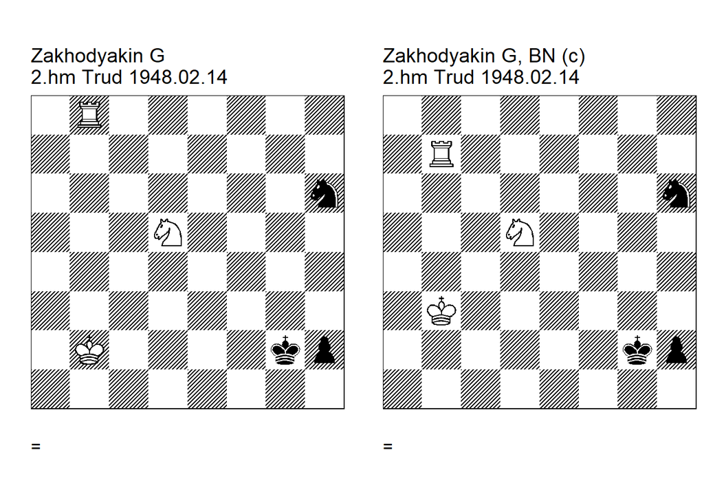

```
Zakhodyakin G
2.hm Trud 1948.02.14
=0104.01b2g2 cook U1
1R6/8/7n/3N4/8/8/1K4kp/8 w - - 0 1
U1: Hildebrand=A Tidskrift for Schack=12 12/1950 U1: Pettersson=B Tidskrift for Schack=2
2/1951. 1. Ka2 (1. Nf4+! <cook AH> 1... Kf2 2. Nh3+ Kg2 (2... Ke2 3. Re8+ Kf3 4. Rf8+ Kg2
5. Nf2) 3. Nf4+ Kf3 4. Rb3+ Kxf4 5. Rh3)  (1. Ne3+! <cook AH> 1... Kf3 2. Rf8+ Kxe3 3.
Rf1)  (1. Ka1! <cook BP> ) 1... h1=Q 2. Rb1 Qh4 3. Rb2+ Kf3 4. Rb3+ Ke2 5. Rb2+ Kd3 6.
Rb3+ 1/2-1/2.


Zakhodyakin G, BN (c)
2.hm Trud 1948.02.14
=0104.01b2g2 (c)
8/1R6/7n/3N4/8/1K6/6kp/8 w - - 0 1
correction: Neuenschwander=B beatochess 08/05/2024. 1. Ka2 (1. Nf4+ Kf3)  (1. Ne3+ Kf3)
1... h1=Q 2. Rb1 Qh4 3. Rb2+ Kf3 4. Rb3+ Ke2 5. Rb2+ Kd3 6. Rb3+ 1/2-1/2.
```

Date: 2024, May 7

File: Zakhodyakin1983e.pgn

An additional pawn prevents the nasty cook **2… Kd7**.

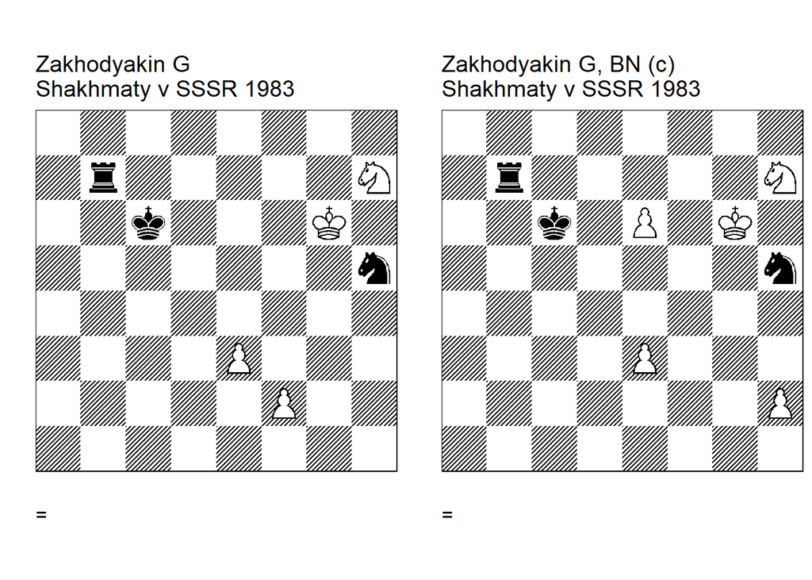

```
Zakhodyakin G
Shakhmaty v SSSR 1983
=0304.20g6c6 cook U3
8/1r5N/2k3K1/7n/8/4P3/5P2/8 w - - 0 1
Shakhmaty v SSSR/3. U3: Alizade=A Shakhmaty v SSSR/11 1983. 1. Ng5 Ng7 2. Nf7 Ne6 (2...
Kd7!  <cook AA> 3. Kxg7 Ke6) 3. Kf6 Kd7 4. Ne5+ Kd6 5. Nf7+ Kd5 6. e4+ 1/2-1/2.


Zakhodyakin G, BN (c)
Shakhmaty v SSSR 1983
=0304.30g6c6 (c)
8/1r5N/2k1P1K1/7n/8/4P3/7P/8 w - - 0 1
correction: Neuenschwander=B beatochess 07/052024. 1. Ng5 Ng7 2. Nf7 Nxe6 3. Kf6 Kd7 4.
Ne5+ Kd6 5. Nf7+ Kd7 (5... Kd5 6. e4+) 6. Ne5+ 1/2-1/2.
```

### =0340.20h2h5 (1982). Correction

Date: 2024, May 7

File: Zakhodyakin1982g.pgn

The first two moves can be interchanged. This can easily be fixed by placing the black bishop on a different square, allowing the refutation **Rg7** after **1. Kh1**. The correction adds a bit more spice, at the cost of an additional white pawn.

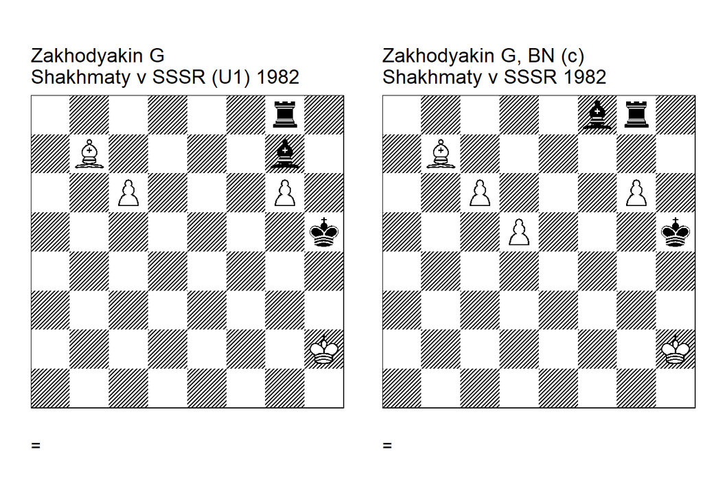

```
Zakhodyakin G
Shakhmaty v SSSR (U1) 1982
=0340.20h2h5
6r1/1B4b1/2P3P1/7k/8/8/7K/8 w - - 0 1
Shakhmaty v SSSR/9. (U1) Neuenschwander=B beatochess 07/05/2024. 1. c7! (1. Kh1 <minor
dual> 1... Be5 2. c7) 1... Be5+ 2. Kh1 (2. Kh3? Bxc7 3. Bd5 Re8! 4. g7 Re3+ 5. Kg2 Rg3+)
2... Bxc7 3. Bd5! Rg7 (3... Rxg6 4. Bf7) 4. Bf7! 1/2-1/2.


Zakhodyakin G, BN (c)
Shakhmaty v SSSR 1982
=0340.30h2h5 (c)
5br1/1B6/2P3P1/3P3k/8/8/7K/8 w - - 0 1
correction: Neuenschwander=B beatochess 07/05/2024.  1. c7! (1. Kh1? Rg7) 1... Bd6+ 2.
Kh1! (2. Kh3? Bxc7 3. d6 Bxd6 4. Bd5 Re8 5. g7 Re3+ 6. Kg2 Rg3+) 2... Bxc7 3. d6! Bxd6 4.
Bd5! Rg7 5. Bf7 1/2-1/2.
```

Date: 2024, May 7

File: Zakhodyakin1982f.pgn

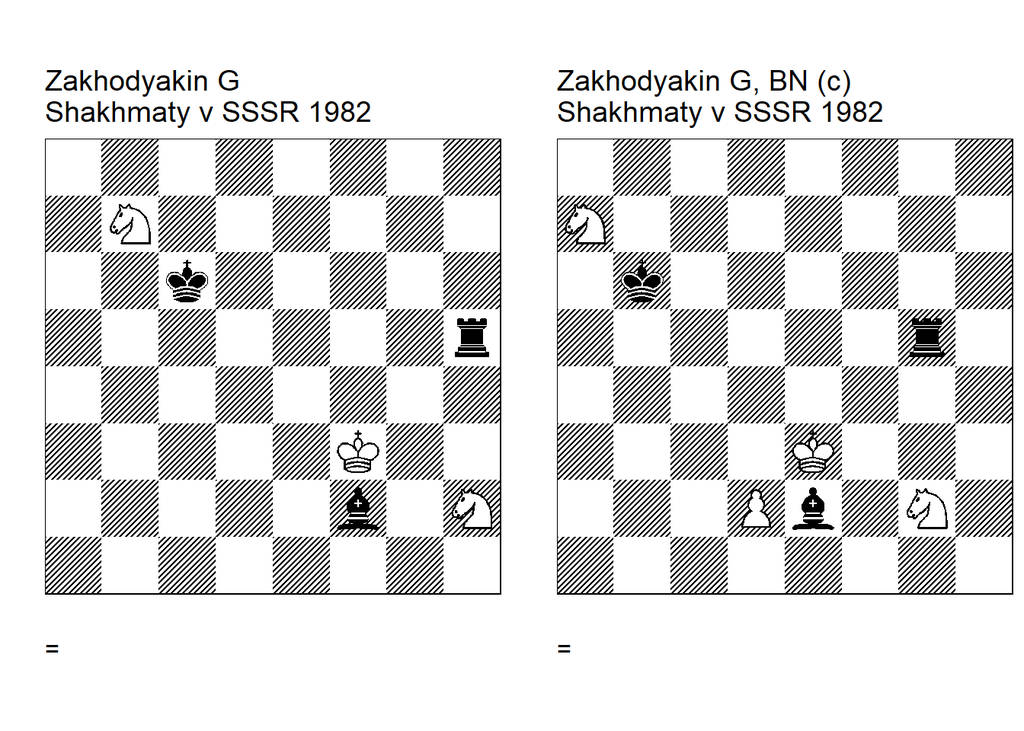

```
Zakhodyakin G
Shakhmaty v SSSR 1982
=0332.00f3c6 cook U1 U3
8/1N6/2k5/7r/8/5K2/5b1N/8 w - - 0 1
Shakhmaty v SSSR/12. U1: Shardakov=A Shakhmaty v SSSR/11 1983 U3: Beasley=J HHdbIII#20147
3-2-2002 U3: Conrady=H HHdbIII#20147 1-4-2005. Comment: Neuenschwander=B beatochess
07/05/2024. 1. Nd8+ (1. Na5+ Kb5 2. Ng4 (2. Kxf2 Rxh2+ 3. Kg3 Rd2)  (2. Nf1! <cook
AS><comment BN: according to tablebase, this RBvNN ending is lost> 2... Bb6 3. Nb3 Rf5+
4. Ke2 Rf2+ 5. Ke1 Kc4 6. Nfd2+ Kd3 7. Kd1! Be3 (7... Rh2 8. Nc1+ Kc3 9. Ne2+) 8. Nc1+
Kd4 9. Ne2+)  2... Bb6 3. Nb3 Rh3+) 1... Kd7 2. Nf7! Rf5+ (2... Rxh2 3. Ne5+ Ke6 4. Ng4)
3. Kg2! Rxf7 (3... Be3! <cook HC> )  (3... Kc6! <cook HC> )  (3... Ke6! <cook HC> )
(3... Bb6! <cook HC> )  (3... Ba7! <cook HC> ) 4. Nf3! 1/2-1/2.


Zakhodyakin G, BN (c)
Shakhmaty v SSSR 1982
=0332.10e3b6 (c)
8/N7/1k6/6r1/8/4K3/3Pb1N1/8 w - - 0 1
correction: Neuenschwander=B beatochess 07/05/2024. 1. Nc8+ Kc7 2. Ne7 Re5+ 3. Kf2 Rxe7
4. Ne3 1/2-1/2.
```

Date: 2024, May 7

File: Zakhodyakin1982e.pgn

**1. Rf8** and **1. Ka2** (followd by Rf8) cook the study.

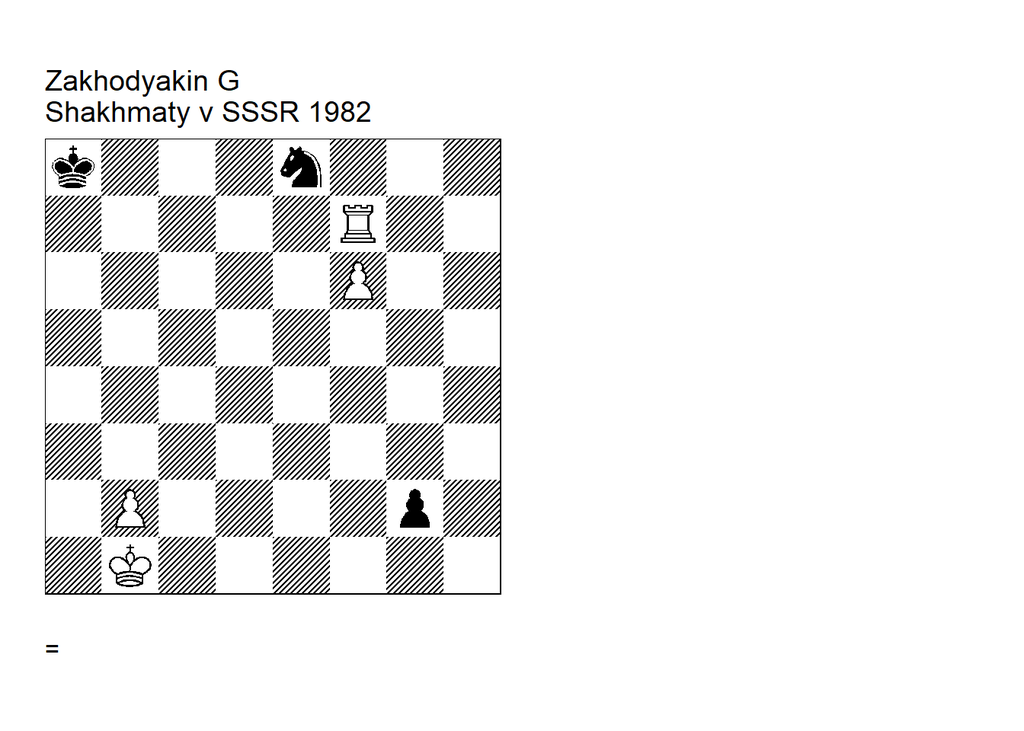

```
Zakhodyakin G
Shakhmaty v SSSR 1982
=0103.21b1a8 cook U2
k3n3/5R2/5P2/8/8/8/1P4p1/1K6 w - - 0 1
Shakhmaty v SSSR/12. (U2): Beasley=J HHdbIII#20145 3-2-2002. U1: Neuenschwander=B
beatochess 07/05/2024. 1. Ra7+! (1. Rf8! <cook BN> 1... g1=Q+ 2. Ka2)  (1. Ka2! <cook BN>
1... g1=Q 2. Rf8) 1... Kb8 (1... Kxa7 2. f7 g1=Q+ 3. Ka2) 2. Rb7+! (2. Ka2! <minor_dual
JB> ) 2... Kxb7 3. f7 g1=Q+ 4. Ka2 Qa7+ 5. Kb1 1/2-1/2.
```

Date: 2024, May 7

File: Zakhodyakin1982d.pgn

In Zakhodyakin’s original study, **1. Rh4** is not a cook due to **1. … Nd5**. Moreover, there are additional cooks on move 4 and 5. The same-material correction has two main lines, depending on Black’s choice on move 5.

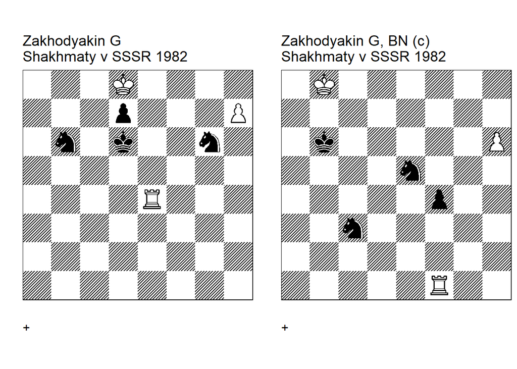

```
Zakhodyakin G
Shakhmaty v SSSR 1982
+0106.11d8d6 cook U1 U3
3K4/3p3P/1n1k2n1/8/4R3/8/8/8 w - - 0 1
Shakhmaty v SSSR/12. U1: Isakov=V Shakhmaty v SSSR/2 1985 U3: Haworth=G Bleicher=E
HHdbIV#50732 31-10-2009 Comment Neuenschwander=B beatochess 07/05/2024 . 1. Rg4 (1. Ke8!
<cook VI> 1... Nh8 2. Kf8)  (1. Rh4! <cook VI> 1... Ne5 (1... Nd5! = <comment BN> ) 2.
Rh6+ Kc5 3. Rh5) 1... Nh8 2. Rg8 Nd5! 3. Rxh8 Nf6 4. Kc8 Kc6 (4... Kc5 <cook BN> 5. Kc7
(5. Kb7 Kb4)  5... d5 =) 5. Kb8 Kb6 (5... Kb5 <cook BN> ) 6. Ka8! Ka6 (6... Ka5! <cook
GH/EB> 7. Rd8 Nxh7 8. Rxd7 Nf6) 7. Rd8! Nxh7 8. Rxd7 Ng5 (8... Nf8 9. Rf7) 9. Rd6+ Kb5
10. Rd5+ 1-0.


Zakhodyakin G, BN (c)
Shakhmaty v SSSR 1982
+0106.11b8b6 (c)
1K6/8/1k5P/4n3/5p2/2n5/8/5R2 w - - 0 1
correction: Neuenschwander=B beatochess 07/05/2024. 1. h7 (1. Rxf4? Nd5! 2. h7 (2. Rf5
Ne7) 2... Ng6 3. Rg4 Nde7) 1... Ng6 2. Rg1 (2. Re1? Kb5!! ( 2... Kc5 3. Re6 Nh8 4. Re8)
3. Re6 Nh8 4. Re8 Nd5 5. Rxh8 Nf6 6. Kc7 Kc4 7. Kd6 Kd3 8. Ke5 Nxh7 =) 2... Nh8 3. Rg8
Ne4 4. Rxh8 Nf6 5. Ka8! Ka6 (5... Ka5 <main> 6. Rf8! (6. Rg8? Nxh7 7. Rg7 Nf6) 6... Nxh7
7. Rf7 Ng5 (7... Kb4 8. Rxh7 Kc3 9. Rf7) 8. Rf5+) 6. Rg8! (6. Rf8? Nxh7 7. Rf7 Ng5 8.
Rf6+ Kb5 9. Rf5+ Kc4 10. Rxg5 Kd3) 6... Nxh7 7. Rg7 Nf8 8. Rf7 Ne6 9. Rf6 1-0.
```

Date: 2024, May 5

File: Zakhodyakin1979b.pgn

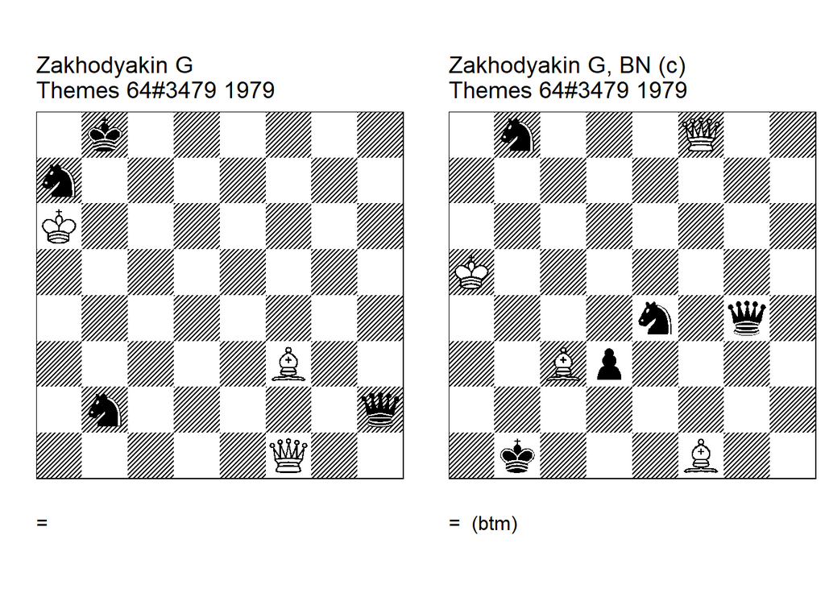

```
Zakhodyakin G
Themes 64#3479 1979
=4016.00a6b8 cook U3
1k6/n7/K7/8/8/5B2/1n5q/5Q2 w - - 0 1
Th mes 64=94 Th mes 64/4-6. U3: Perkonoja=P Th mes 64=96 10-12/1979. 1. Bc6! Qd6 2. Qc4!
Qa3+ (2... Nd3! <cook PP> ) 3. Ba4! Qd6+ (3... Nxc4) 4. Bc6! Nxc4 1/2-1/2.


Zakhodyakin G, BN (c)
Themes 64#3479 1979
=4026.01a5b1 (c)
1n3Q2/8/8/K7/4n1q1/2Bp4/8/1k3B2 b - - 0 1
correction: Neuenschwander=B beatochess 05/05/2024. 1... Qh5+ 2. Kb4 (2. Kb6? Nd7+)  (2.
Ka4? Nxc3+) 2... Nc6+ (2... Na6+ 3. Kc4 d2 4. Bd3+ Ka2 5. Bxd2 Nxd2+ 6. Kc3 Qa5+ 7. Kc2)
3. Ka3 (3. Kc4? d2 4. Bd3+ Ka2 5. Bxd2 (5. Qa8+ Na5+) 5... Nxd2+ 6. Kc3 Qa5+ 7. Kc2 Nd4+
8. Kd1 N2f3) 3... Qd5 4. Bxd3+! Qxd3 5. Qc5!! Qa6+ (5... Nxc5 =)  (5... Nxc3 6. Qxc6 =)
6. Ba5 Qd3+ (6... Nxa5 7. Qb5+! Qxb5 =) 7. Bc3 1/2-1/2.
```

Date: 2024, May 1

File: Zakhodyakin1981c.pgn

The modfication keeps the main idea but ends in yet another positional draw.

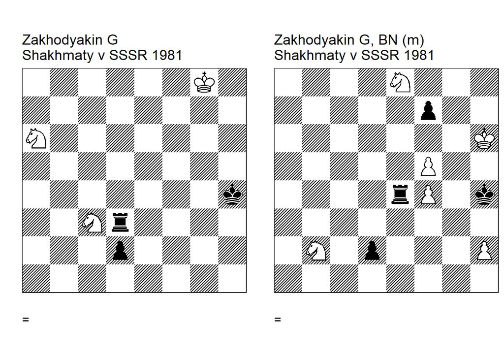

```
Zakhodyakin G
Shakhmaty v SSSR 1981
=0302.01g8h4 cook U3
6K1/8/N7/8/7k/2Nr4/3p4/8 w - - 0 1
Shakhmaty v SSSR/5. U3: Zabolotsky=V Shakhmaty v SSSR/11 1982 U3: Conrady=H HHdbIII#21038
27-5-2001. 1. Nd1 Rg3+ 2. Kh8! Rg1 3. Nc5! (3. Ne3? Re1)  3... Rxd1 4. Ne4! Kh5 5. Kh7
Kh4 (5... Rb1! <cook VZ> 6. Nxd2 Rb7+ 7. Kg8 Kg6 8. Kf8 Rb4!) 6. Kh6 (6. Kh8? Rc1) 6...
Rc1! <cook HC> 1/2-1/2.


Zakhodyakin G, BN (m)
Shakhmaty v SSSR 1981
=0302.32h4h6 (m)
4N3/5p2/7K/5P2/4rP1k/8/1N1p3P/8 w - - 0 1
modification: Neuenschwander beatochess 01/05/2024. 1. Nf6! (1. Nd6? Rb4! 2. Nd1 Rb6)
1... Re1 (1... Rxf4 2. Kg7 Kg5 3. Kxf7) 2. h3! (2. Nd1? Rxd1 3. Ne4 Rf1! 4. Nxd2 Rxf4 5.
Kg7 Rxf5 6. Ne4 Rf1! 7. Nf6 Kg5 8. Nh7+ Kg4 9. Nf6+ Kf5) 2... Rb1 (2... Kxh3 3. Kg7) 3.
Nd1! Rxd1 4. Ne4 Rf1 5. Nxd2 Rxf4 6. Kg7 Rxf5 7. Ne4 Rf1 8. Nf6 Kg5 9. Nh7+ Kh5 10. Nf6+
Kg5 (10... Kh4 11. Kxf7 Kg5 12. h4+) 11. Nh7+ 1/2-1/2.
```

### +3230.01c6b8 (1981). Correction

Date: 2024, April 30

File: Zakhodyakin1981b.pgn

One of several R vs. B studies. The additional black pawn on h4 removes the cooks.

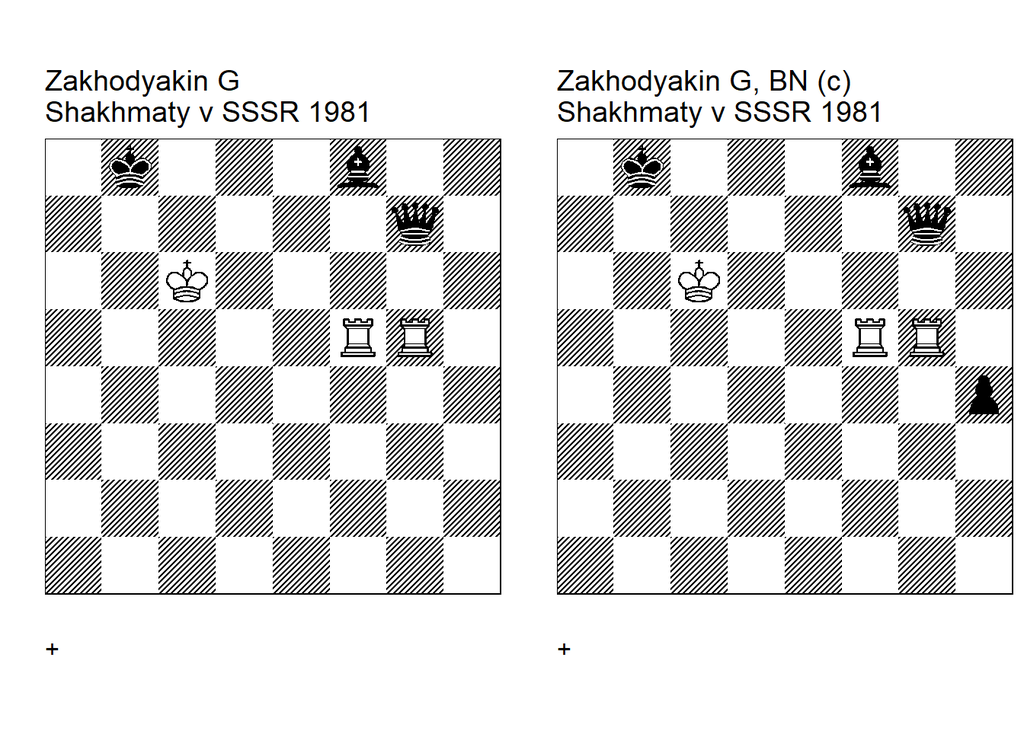

```
Zakhodyakin G
Shakhmaty v SSSR 1981
+3230.00c6b8 cook U2
1k3b2/6q1/2K5/5RR1/8/8/8/8 w - - 0 1
Shakhmaty v SSSR/1. U2: Afek=Y HHdbVI 6-8-2020. 1. Rb5+ Ka8 (1... Kc8 2. Rxg7 Bxg7 3.
Rg5) 2. Ra5+ Qa7 (2... Kb8 3. Rgb5+) 3. Rxa7+ (3. Rh5! <cook YA> )  (3. Rgd5!  <cook YA>
) 3... Kxa7 4. Rg4! (4. Rg6! <cook YA> ) 4... Bh6 5. Kc7 Ka6 6. Rg6+ 1-0.


Zakhodyakin G, BN (c)
Shakhmaty v SSSR 1981
+3230.01c6b8 (c)
1k3b2/6q1/2K5/5RR1/7p/8/8/8 w - - 0 1
correction: Neuenschwander=B beatochess beatochess30/04/ 2024. 1. Rb5+ Ka8 2. Ra5+ Qa7
(2... Kb8 3. Rgb5+) 3. Rxa7+ (3. Rgd5? Qxa5) 3... Kxa7 4. Rg4! Bh6 (4... h3 5. Rh4 h2 6.
Rxh2 Bb4 (6... Bg7 7. Rh7) 7. Ra2+ Kb8 8. Rb2) 5. Kc7 Ka6 6. Rg6+ 1-0.
```

Date: 2024, April 25

File: Zakhodyakin1979a.pgn

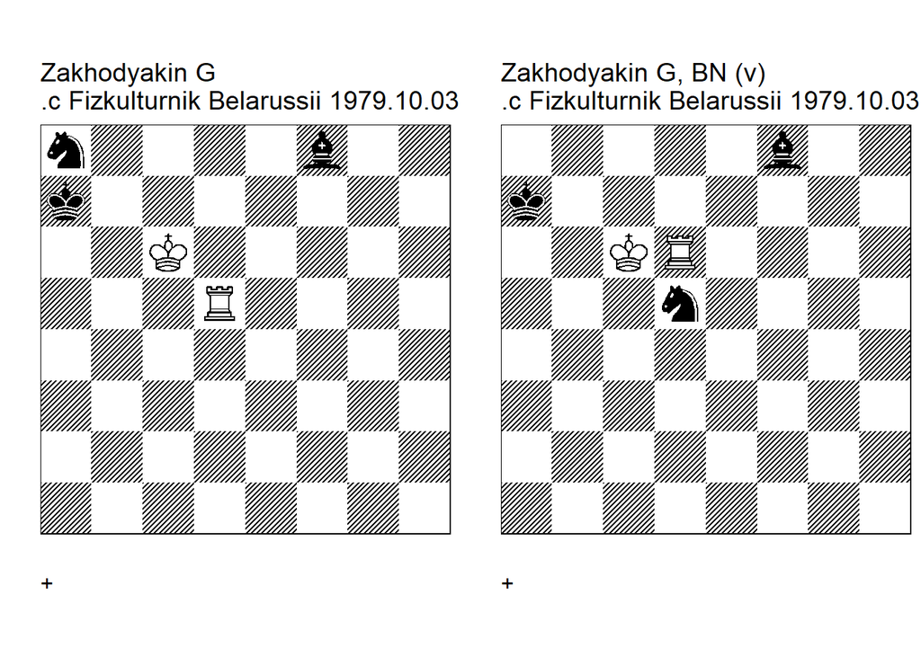

```
Zakhodyakin G
.c Fizkulturnik Belarussii 1979.10.03
+0133.00c6a7 cook U3
n4b2/k7/2K5/3R4/8/8/8/8 w - - 0 1
(EG#04964). U3: Conrady=H HHdbIII#22486 27-5-2001 U2: Neuenschwander=B beatochess
25/04/2024. 1. Rd7+ Nc7 (1... Ka6 2. Rd8 Nb6! <cook HC> 3. Rxf8 Ka5 4. Rf5+ Ka6) 2. Rxc7+
(2. Kxc7! <cook BN> 2... Ka6 3. Rd5!) 2... Kb8 3. Rh7 Ba3 4. Rh1 Be7 5. Rh8+ Ka7 6. Rh7
1-0.


Zakhodyakin G, BN (v)
.c Fizkulturnik Belarussii 1979.10.03
+0133.00c6a7 (v)
5b2/k7/2KR4/3n4/8/8/8/8 w - - 0 1
version: Neuenschwander=B beatochess 25/04/2024. 1. Rd7+ Kb8 (1... Ka6 2. Rxd5!)  (1...
Nc7 2. Rxc7+ ( <or> 2. Kxc7) 2... Kb8 3. Rh7 Ba3 4. Rh1 Be7 5. Rh8+ Ka7 6. Rh7) 2. Rd8+
Ka7 3. Rxf8! (3. Rxd5? Bh6!) 3... Nb4+ 4. Kb5 1-0.
```

### +0130.01b4b1 (1978). Correction

Date: 2024, April 25

In addition to Afek’s cook, there is also the cook **3. Rb4+**. Afek’s cook can be eliminated by an additional black pawn, and uniqueness of the solution can be ensured by changing the main line to **2. Bc8**.

File: Zakhodyakin1978a.pgn

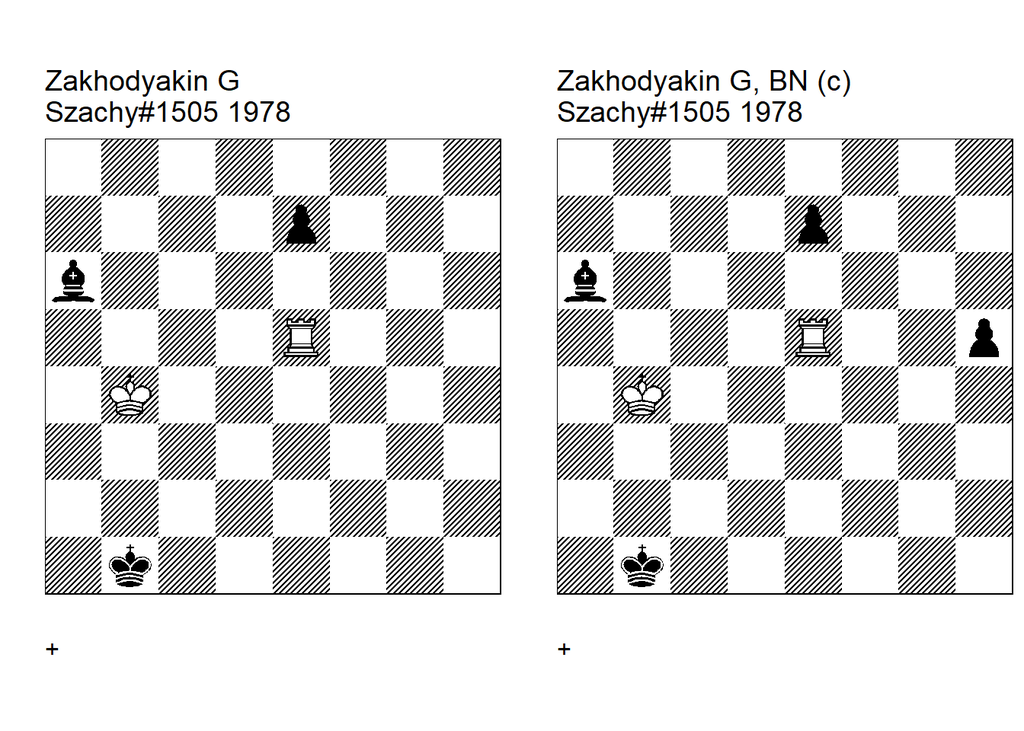

```
Zakhodyakin G
Szachy#1505 1978
+0130.01b4b1 cook U2
8/4p3/b7/4R3/1K6/8/8/1k6 w - - 0 1
Szachy=11(383) Szachy/11. U2: Afek=Y HHdbVI 6-8-2020 U2: Neuenschwander=B beatochess
25/04/2024. 1. Kc3! e6! 2. Re4! (2. Rg5! <cook YA> 2... Bc8 3. Rg1+ Ka2 4. Rg2+ Kb1 5.
Kb3) 2... e5 3. Rxe5 (3. Rb4+! <cook BN>  3... Kc1 4. Ra4) 3... Bc8 4. Kb3 Kc1 5. Rc5+
1-0.


Zakhodyakin G, BN (c)
Szachy#1505 1978
+0130.01b4b1 (c)
8/4p3/b7/4R2p/1K6/8/8/1k6 w - - 0 1
correction: Neuenschwander=B beatochess 25/04/2024. 1. Kc3 e6 2. Re4! (2. Rg5? h4!)  (2.
Rxh5? Bc8!) 2... Bc8 (2... h4 3. Rb4+ (3. Rxh4 Bc8) 3... Kc1 4. Ra4)  (2... e5 3. Rxe5
<or> 3.Rb4+ ) 3. Kb3 Kc1 4. Rc4+ 1-0.
```

### =0840.11a1g8 (1971). Correction

Date: 2024, April 25

File: Zakhodyakin1971.pgn

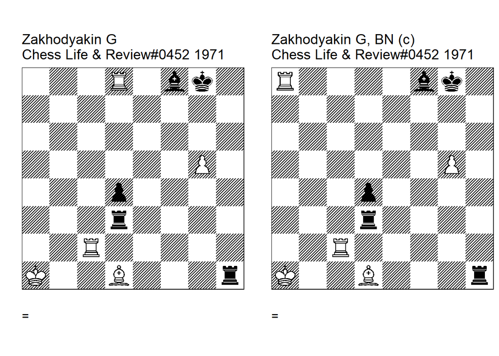

```
Zakhodyakin G
Chess Life & Review#0452 1971
=0840.11a1g8 cook U1
3R1bk1/8/8/6P1/3p4/3r4/2R5/K2B3r w - - 0 1
Chess Life & Review=8 Chess Life & Review/8. U1: Brieger=R Szusz=P Chess Life & Review=4
4/1972 U1: Neuenschwander=B beatochess 25/05/2024. 1. Kb2! (1. Rf2!  <cook RB/PS> 1...
Rhxd1+ 2. Kb2 R1d2+ 3. Rxd2 Rxd2+ 4. Kc1 Rd3 5. Kc2 Rc3+ 6. Kd2 Rc4 7. Kd3)  (1. Rc1!
<cook BN> 1... Rdxd1 2. Rxd1 Rxd1+ 3. Kb2 Kf7 4. Kc2) 1... Rhxd1 2. Rxf8+! Kxf8 3. Rf2+
Kg8! 4. Kc2! Kg7 5. Re2! (5. Rh2? Ra3! 6. Kxd1 Ra1+ 7. Kc2 Ra2+)  (5. Rg2? Kg6!) 1/2-1/2.


Zakhodyakin G, BN (c)
Chess Life & Review#0452 1971
=0840.11a1g8 (c)
R4bk1/8/8/6P1/3p4/3r4/2R5/K2B3r w - - 0 1
correction: Neuenschwander=B beatochess 25/05/2024. 1. Kb2! (1. Rf2? Rhxd1+ 2. Kb2 R1d2+
3. Rxd2 Rxd2+ 4. Kc1 Rd3 5. Kc2 Rc3+ 6. Kd2 Kf7) 1... Rhxd1 (1... Rdxd1 2. Rf2) 2. Rxf8+!
Kxf8 3. Rf2+ Kg8 4. Kc2 Kg7 5. Re2! (5. Rh2? Ra3 6. Kxd1 Ra1+)  (5. Rg2? Kg6) 5... Kg6 6.
Rg2 1/2-1/2.
```

### +01700.00d3a8 (1969). Modification

Date: 2024, April 24

File: Zakhodyakin1969.pgn

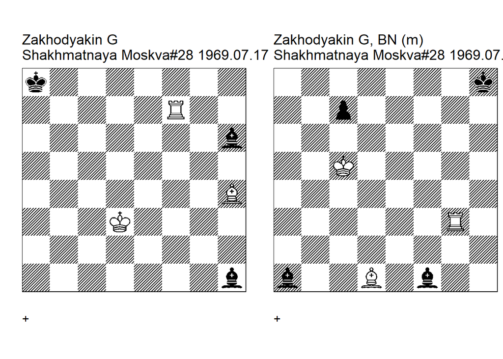

```
Zakhodyakin G
Shakhmatnaya Moskva#28 1969.07.17
+0170.00d3a8 cook U2 U1
k7/5R2/7b/8/7B/3K4/8/7b w - - 0 1
Shakhmatnaya Moskva=13(279) . U2: Shakhmatnaya Moskva=3(317) 10-2-1971 U1 U2:
Neuenschwander=B batochess 24/04/2024. 1. Rf6! 1.Kd4, 1.Kc4, 1.Kc3, 1.Bg3, 1.Bf2, <cooks
BN> 1... Bg7 2. Re6! (2. Rf5  <cook BN> ) 2... Bb2 3. Re8+ <cooks BN> 1.Re2, 1.Kc4,
1.Bg5, 1.Re1, 1.Bg3  (3. Bf2! <cook> ) 3... Ka7 4. Bf2+ Ka6 5. Re6+ Ka5 6. Kc4 Bb7 7.
Be1+ Ka4 8. Rb6 1-0.


Zakhodyakin G, BN (m)
Shakhmatnaya Moskva#28 1969.07.17
+0170.01c5h8 (m)
7k/2p5/8/2K5/8/6R1/8/b2B1b2 w - - 0 1
modification: Neuenschwander=B beatochess 24/04/2024. 1. Rf3 Bg2 2. Rf4 Bb7 3. Rb4 Bg2 4.
Rh4+ Kg8 5. Rg4+ 1-0.
```

### =0510.12d1h6 (1965). Correction

Date: 2024, April 23

File: Zakhodyakin1965b.pgn

One of Zakhodyakin’s most spectacular positional draws. The correction with the additional white h-pawn is even more spectacular.

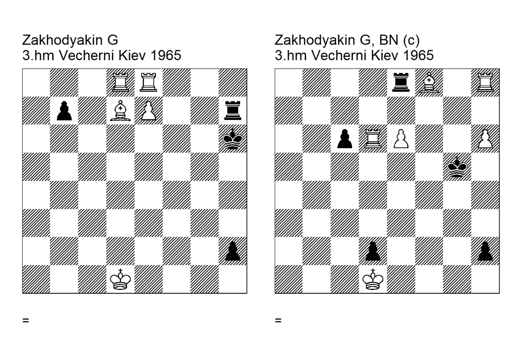

```
Zakhodyakin G
3.hm Vecherni Kiev 1965
=0510.12d1h6 cook U1 U2
3RR3/1p1BP2r/7k/8/8/8/7p/3K4 w - - 0 1
(EG#00059). U1: Veitch=W EG=3 1/1966 U2: Aloni=H Shahmat 1966. 1. Bc6 (1. Kc2! <cook WV>
h1=Q 2. Bb5 Qe4+ 3. Kb3 Rxe7 4. Rxe7 Qxe7 5. Rd5) 1... bxc6 2. Rd6+ Kh5 3. Rd5+ (3. Re6!
<cook HA> h1=Q+ 4. Re1 Qd5+ 5. Kc2 Kh6 6. Re2) 3... cxd5 4. Rg8 h1=Q+ 5. Kd2 Qh2+ 6. Kd1
1/2-1/2.


Zakhodyakin G, BN (c)
3.hm Vecherni Kiev 1965
=0510.23d1g5 (c)
4rB1R/8/2pRP2P/6k1/8/8/3p3p/3K4 w - - 0 1
correction: Neuenschwander=B beatochess 23/04/2024. 1. Be7+! Rxe7 2. Rg8+ Kh5 (2... Kf6
3. Rf8+ Ke5 4. Rf1 Kxd6 5. Rh1)  (2... Kh4 3. Rd4+) 3. Rd5+! cxd5 4. h7! h1=Q+ 5. Kxd2
Qh2+ 6. Kd1 Qh1+ 7. Kd2 Rxh7 8. e7 Qh2+ 9. Kd1 Qh1+ 10. Kd2 1/2-1/2.
```

### =0305.01f4b1 (1965). Correction

Date: 2024, April 23

File: Zakhodyakin1965a.pgn

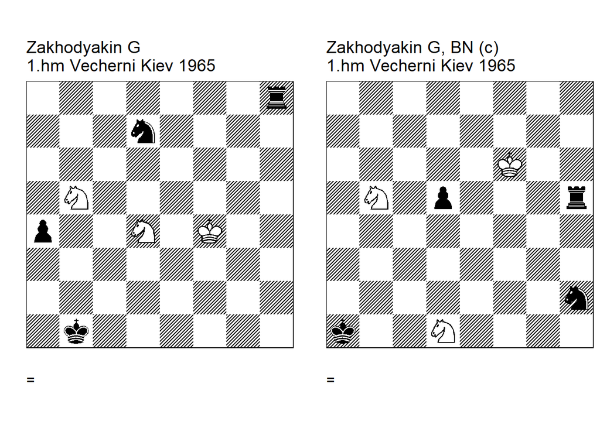

```
Zakhodyakin G
1.hm Vecherni Kiev 1965
=0305.01f4b1 cook U2
7r/3n4/8/1N6/p2N1K2/8/8/1k6 w - - 0 1
(EG#00057). U2: Garcia=M EG=173 7/2008. 1. Nc3+ Ka1 2. Nxa4 Rc8 3. Ke4 ( 3. Nb3+! <cook
MG> Ka2 4. Nd2 Ka3 5. Nc3) 3... Rc4 4. Nc5 Nxc5+ 5. Kd5 Rc3 6. Ne2 Re3 7. Nd4 Rc3 8. Ne2
Rc2 9. Nd4 Rc1 10. Ne2 Re1 11. Nd4 1/2-1/2.


Zakhodyakin G, BN (c)
1.hm Vecherni Kiev 1965
=0305.01f6a1 (c)
8/8/5K2/1N1p3r/8/8/7n/k2N4 w - - 0 1
correction: Neuenschwander=B beatochess 23/04/2024. 1. Nd4 (1. Ndc3? Kb2 2. Ke6 d4)  (1.
Ke6? Nf3) 1... Ng4+ (1... Rh3 2. Ne3 Nf3 3. Ne6) 2. Ke6 Rh3 3. Kxd5 Rd3 4. Ne3! Nxe3+ 5.
Ke4 Rc3 6. Nb5 Rb3 7. Nd4 Ra3 8. Nb5 Ra5 9. Nd4 Ra3 10. Nb5 Rb3 11. Nd4 Rc3 12. Nb5 Rc5
13. Nd4 Rc3 14. Nb5 1/2-1/2.
```

### =0002.03g5g1 (1962). Correction

Date: 2024, April 22

File: Zakhodyakin1962b.pgn

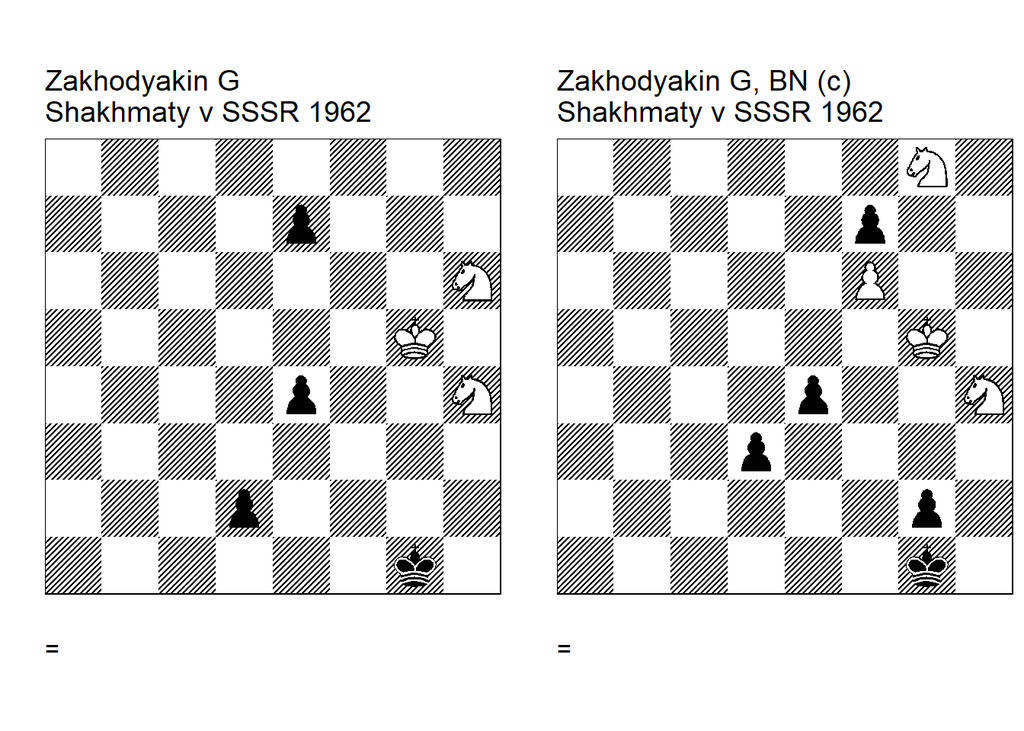

```
Zakhodyakin G
Shakhmaty v SSSR 1962
=0002.03g5g1 cook U3
8/4p3/7N/6K1/4p2N/8/3p4/6k1 w - - 0 1
Shakhmaty v SSSR/10. U3: Lafora=C Dos Caballos en Combate#375 1965. 1. Ng4 d1=Q 2. Ng2!
Qd5+ 3. Kh4 e5 ( 3... Qf5! <cook CL> 4. N2e3 Qg6! 5. Kg3 Qg5 6. Kh3 Qh5+ 7. Kg3 e5) 4.
N2e3 1/2-1/2.


Zakhodyakin G, BN (c)
Shakhmaty v SSSR 1962
=0002.14g5g1 (c)
6N1/5p2/5P2/6K1/4p2N/3p4/6p1/6k1 w - - 0 1
correction: Neuenschwander=B beatochess 22/04/2024. 1. Nh6 d2 2. Ng4 d1=Q 3. Nxg2! Qd5+ (
3... Kxg2 4. Ne3+) 4. Kh4! (4. Kh6? Qf5 (4... Qd2+? 5. N2e3) )  (4. Kf4 Qd6+) 4... Qf5 5.
N2e3 1/2-1/2.
```

### +0310.10g8a7 (1962). Correction

Date: 2024, April 22

File: Zakhodyakin1962a.pgn

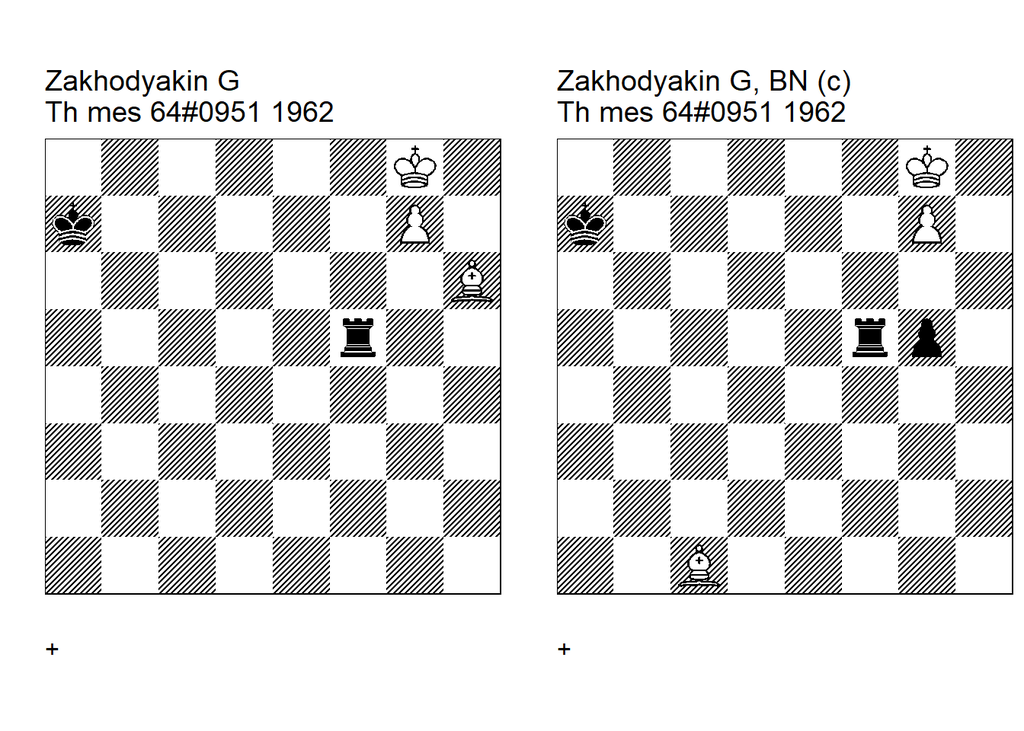

```
Zakhodyakin G
Th mes 64#0951 1962
+0310.10g8a7 cook U2
6K1/k5P1/7B/5r2/8/8/8/8 w - - 0 1
Th mes 64=28 Th mes 64/10-12. U2: Th mes 64=30 4-6/1963. 1. Kh8 Rb5 2. Be3+ (2. g8=Q!
<cook> Rb8 3. Bf8) 2... Ka8 3. Bc5 Rb8+ 4. Bf8 Rb1 5. g8=Q Rh1+ 6. Bh6+ 1-0.


Zakhodyakin G, BN (c)
Th mes 64#0951 1962
+0310.11g8a7 (c)
6K1/k5P1/8/5rp1/8/8/8/2B5 w - - 0 1
correction: Neuenschwander=B beatochess 22/04/2024. 1. Kh8 Rb5 2. Be3+ Ka8 3. Bc5 Rb8+ 4.
Bf8 Rb1 5. g8=Q (5. Bd6? Rh1+ 6. Kg8 Rh6 7. Kf7 Rh7) 5... Rh1+ 6. Bh6+ 1-0.
```

### +0014.13e4a6 (1948). Correction

Date: 2024, April 22

File: Zakhodyakin1948b.pgn

This study was quite difficult to fix.

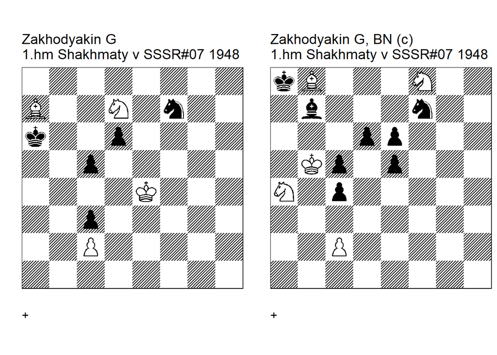

```
Zakhodyakin G
1.hm Shakhmaty v SSSR#07 1948
+0014.13e4a6 cook U3
8/B2N1n2/k2p4/2p5/4K3/2p5/2P5/8 w - - 0 1
Shakhmaty v SSSR/3. U3: (HHdbII#20443 1948) U3: Paavilainen=J Suomen Tehtavaniekat=1
4-4-2008. 1. Bb8 (1. Bb6? Kb5 2. Kf5 Kc6 3. Kg6 Nh8+ 4. Kg7 Kxd7 5. Ba5 Ke6 6. Kxh8 d5!
7. Bxc3 d4 8. Be1 c4 9. Kg7 c3) 1... Kb7 (1... Kb5! <cook> 2. Kd5 Ng5 3. Nf6 (3. Bxd6 Nf3
4. Nxc5 Ne1 5. Ne4 Nxc2 6. Nxc3+ Ka5 7. Kc5 Na3 8. Bc7+ Ka6 9. Bf4 Ka5 10. Bc1 Nc2 11.
Bd2 Na3) 3... Nf3 4. Ng4 Kb4! 5. Bxd6 Ka3 6. Bxc5+ Kb2 7. Ne3 Ne1 8. Kc4 Nxc2 9. Nd1+ Kc1
10. Nxc3 Kb2 ) 2. Kd5 Kc8 3. Kc6! (3. Ke6? Ng5+ 4. Kxd6 Nf3) 3... Nd8+ 4. Kxd6 Kb7! (
4... Nb7+ 5. Ke7 Na5 6. Bf4! Nc6+!  <cook JP>  (6... Nc4 7. Bc1! Nd2 8. Nxc5 Nf3 9. Ne6)
7. Kd6 Nd4 8. Ne5! Nxc2 9. Kxc5 Na3! (9... Ne1? 10. Kd4 Nc2+ (10... c2 11. Bc1 Kc7 12.
Ke4 Ng2 (12... Kd6 13. Ng6 Ke6 14. Nf4+) 13. Ng6 Kd7 14. Kf3 Ne1+ 15. Ke2 Ng2 16. Kf2)
11. Kxc3 Na3 12. Kb4 Nc2+ 13. Kc5! Kb7 14. Bd2 Ka6 15. Nf3 Na3 16. Nd4) 10. Nf3 Nb1 11.
Ng5! Nd2 (11... c2? 12. Kb4 Kd7 13. Kb3 Ke7 14. Bc1 Kf6 15. Nf3 Kf5 16. Kxc2 Ke4 17. Ne1)
12. Kb4) 5. Ne5! (5. Ke7? Nc6+)  (5. Bc7? Nf7+) 5... Kxb8 6. Kd7! Nb7 7. Nc6+ Ka8 8. Ke6!
c4 9. Kd5! 1-0.


Zakhodyakin G, BN (c)
1.hm Shakhmaty v SSSR#07 1948
+0045.15b5a8 (c)
kB3N2/1b3n2/3pp3/1Kp1p3/N1p5/8/2P5/8 w - - 0 1
correction: Neuenschwander=B beatochess 22/04/2024. 1. Nd7 ( Black has sufficient
material for equality after 1. Bc7) 1... Bc8 2. Nab6+ Kb7 3. Nxc8 Kxc8 4. Kc6 Nd8+ (4...
e4 5. Bc7) 5. Kxd6 Kb7 (5... Nb7+ 6. Kxe6 Na5 7. Bxe5)  6. Nxe5! Kxb8 7. Kd7 Nb7 8. Nc6+
Ka8 9. Kxe6 c3 10. Ke5! c4 11. Kd5 1-0.
```

### =4016.21a1c1 (1931). Correction

Date: 2024, April 20

File: Zakhodyakin1931d.pgn

The correction of the prize winner is even shorter than the original, but it keeps the main ideas (bishop inference sacrifice and queen sacrifice leading to stalemate).

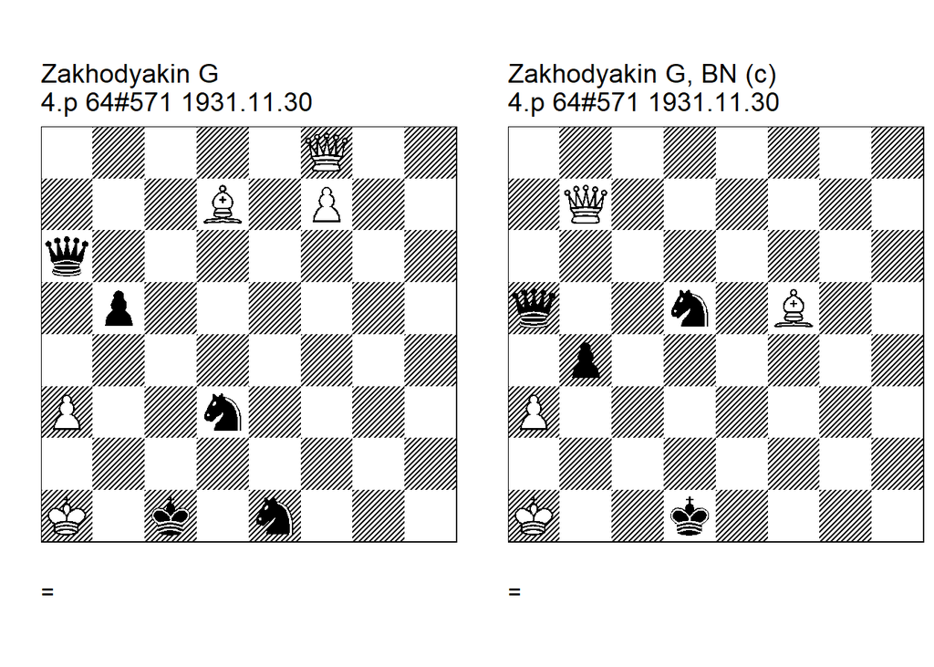

```
Zakhodyakin G
4.p 64#571 1931.11.30
=4016.21a1c1 cook U3
5Q2/3B1P2/q7/1p6/8/P2n4/8/K1k1n3 w - - 0 1
64=21-22 . U3: Beasley=J HHdbIII#53872 3-2-2002 U3: Haworth=G Bleicher=E HHdbIV#14339
1-11-2009. 1. Qc8+ Nc2+ 2. Qxc2+ Kxc2 3. f8=Q b4! (3... Qa7!  <cook JB> 4. Qc8+ Kd2) 4.
Ba4+ Qxa4 5. Qxb4! Nxb4 (5... Qa8! <cook GH/EB>  )  (5... Qa6! <cook GH/EB> )  (5... Qe8!
<cook GH/EB> )  (5... Qc6!  <cook GH/EB> )  (5... Qa7! <cook GH/EB> ) 1/2-1/2.


Zakhodyakin G, BN (c)
4.p 64#571 1931.11.30
=4013.11a1d1 (c)
8/1Q6/8/q2n1B2/1p6/P7/8/K2k4 w - - 0 1
correction: Neuenschwander=B beatochess 20/04/2024. 1. Bc2+! Kc1 (1... Kxc2 2. Qh7+ Kb3
(2... Kc3 3. Qh3+ Kc4 4. Kb2) 3. Qb1+ Kc4 4. Qe4+ Kc5 5. Qc2+ Kb5 6. Qd3+) 2. Ba4! Qxa4
(2... Qc5 3. Qg7) 3. Qxb4! Nxb4 1/2-1/2.
```

Date: 2024, April 19

File: Zakhodyakin1931c.pgn

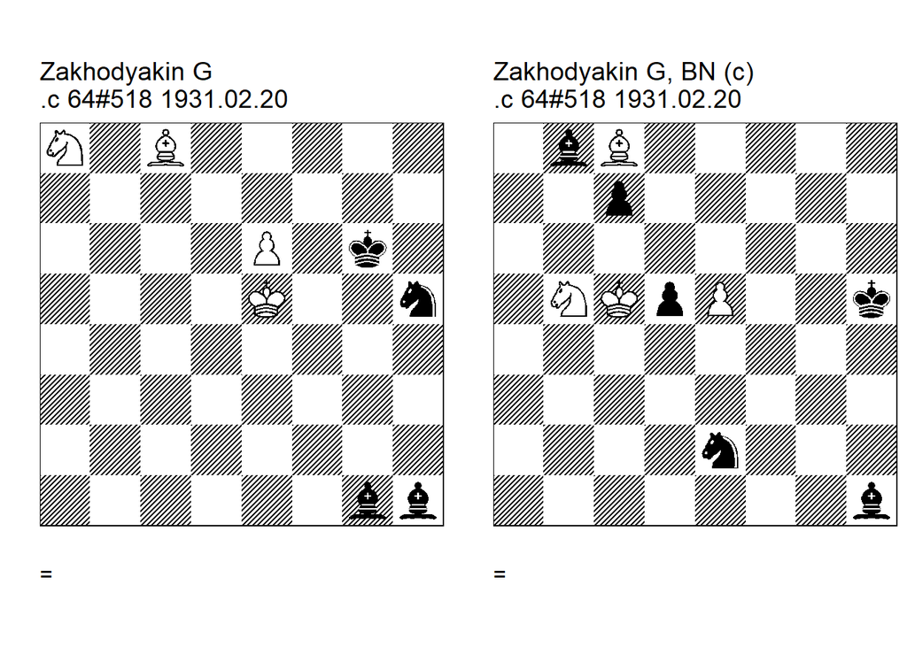

```
Zakhodyakin G
.c 64#518 1931.02.20
=0074.10e5g6 cook U3
N1B5/8/4P1k1/4K2n/8/8/8/6bb w - - 0 1
64=2-3 . U3: Afek=Y HHdbVI 6-8-2020. 1. e7 Nf6! (1... Kf7 2. e8=Q+ Kxe8 3. Nc7+ Kd8 4.
Bg4) 2. Nc7 Bh2+ 3. Ke6 Bxc7 (3... Be4! <cook YA> 4. e8=Q+ Nxe8 5. Nxe8 Bf5+ 6. Kd5 Bxc8)
4. e8=Q+ Nxe8 5. Kd7 Kf7 6. Bb7 Bxb7 1/2-1/2.


Zakhodyakin G, BN (c)
.c 64#518 1931.02.20
=0074.12c5h5 (c)
1bB5/2p5/8/1NKpP2k/8/8/4n3/7b w - - 0 1
correction: Neuenschwander=B beatochess 19/04/2024. 1. e6 Ng3 (1... Kg6 2. Kc6 Kf6 3. Kd7
Be4 4. e7 Bg6 5. Bb7 Nf4 (5... d4 6. Be4 Bf7 7. Bd5) 6. Bc6 Bf5+ 7. Kd8 Ne6+ 8. Kc8 Nd4+
9. Kb7 Nxb5 10. e8=N+ =) 2. e7 (2. Nxc7? Nf5! ( 2... Bxc7? 3. e7 Ne4+ 4. Kc6) 3. Nxd5
Bxd5 4. Kxd5 Ne7+ -/+) 2... Ne4+ 3. Kxd5 (3. Kc6 Nf6 4. Kb7 (4. Nd4 Ba7) 4... c6 5. Kxc6
j 5... Kg6 -/+) 3... Nf6+ 4. Ke6 Kg6 5. Nxc7! (5. Bd7 Bd5+ 6. Ke5 c5+) 5... Bxc7 (5...
Be4 6. Kd6! (6. e8=Q+? Nxe8 7. Nxe8 Bf5+ 8. Ke7 Bxc8 -/+) 6... Ne8+ 7. Kd7 Nxc7 8. e8=Q+
Nxe8 9. Kxe8) 6. e8=Q+! Nxe8 7. Kd7 Kf7 8. Bb7! Bxb7 1/2-1/2.
```

### +0027.01c3e6 (1931). Correction

Date: 2024, April 19

File: Zakhodyakin1931b.pgn

The study seems hard to fix with the original material because two bishops vs. knight (and even a few pawns) will often be lost. The correcction requires quite a bit of additional material.

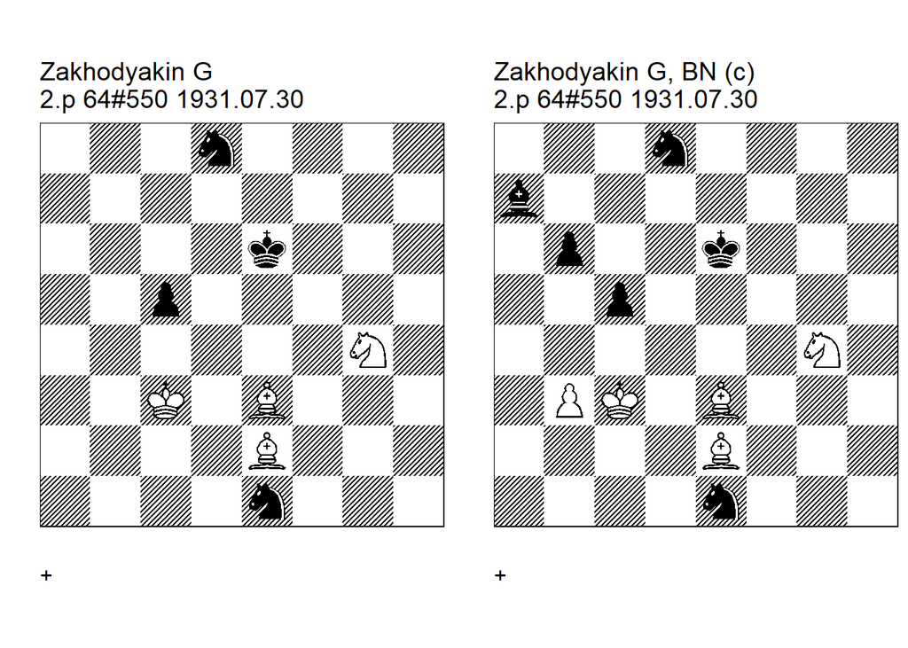

```
Zakhodyakin G
2.p 64#550 1931.07.30
+0027.01c3e6 cook U1 U2
3n4/8/4k3/2p5/6N1/2K1B3/4B3/4n3 w - - 0 1
64=13-14 . U2: 64 Shakhmatnoye Obozrenye=9(728) 5/1985 U1: Beasley=J HHdbIII#53843
3-2-2002. 1. Bd2! (1. Bxc5! <cook JB> ) 1... Ng2 2. Bf1! Nf4! (2... Nh4 3. Bg5 Kf5 4.
Bxh4)  (2... Kf5 3. Nh6+) 3. Bxf4 Kf5 4. Bc7 (4. Be3! <cook> 4... Kxg4 5. Bxc5) 4... Ne6
5. Ne3+! (5. Nh6+? Kg6) 5... Ke4 6. Nd5! Kxd5 7. Bg2# 1-0.


Zakhodyakin G, BN (c)
2.p 64#550 1931.07.30
+0057.12c3e6 (c)
3n4/b7/1p2k3/2p5/6N1/1PK1B3/4B3/4n3 w - - 0 1
correction: Neuenschwander=B beatochess 19/04/2024. 1. Bd2 Ng2 2. Bf1 Nf4 ( 2... Nh4 3.
Bg5)  (2... Kf5 3. Nh6+)  (2... Nf4 3. Bxf4 Kf5 4. Bc7 Ne6 5. Ne3+ Ke4 6. Nd5 Kxd5 7.
Bg2#) 1-0.
```

Date: 2024, April 16

File: Zakhodyakin1982c.pgn

Black’s **3… Nc4** is much more dangerous and requires precise White play. With this as the main line, the study is correct. The version is more parsimonious and interesting due to the fact that the black queen has the square h8 at her disposal.

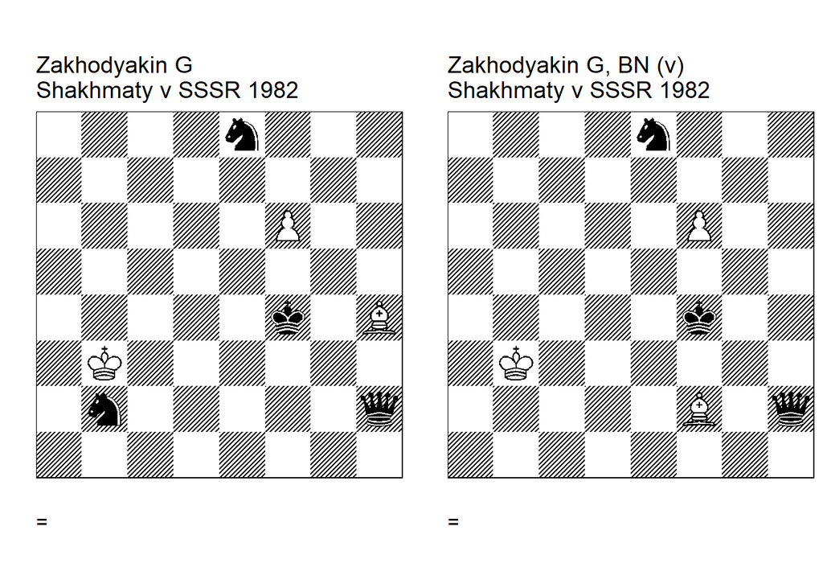

```
Zakhodyakin G
Shakhmaty v SSSR 1982
=3016.10b3f4 cook U2
4n3/8/5P2/8/5k1B/1K6/1n5q/8 w - - 0 1
Shakhmaty v SSSR/9. U2: Beasley=J HHdbIII#20149 3-2-2002. Change main line:
Neuenschwander=B beatochess 16/04/2024. 1. f7 Qh3+ 2. Bg3+! (2. Kb4? Nd3+) (2. Ka2? Qe6+)
2... Qxg3+ 3. Ka2! Nf6 (3... Nc4 is much more dangerous <main line? BN> 4. f8=Q+ Ke4 5.
Qxe8+ Kd3 6. Qe7! Kc3 (6... Qg8 7. Qb4 Qa8+ 8. Kb3 /b1 8... Nd2+ 9. Kb2 Qh8+ 10. Ka2 =)
7. Qe1+! Qxe1) 4. f8=Q Qc3 5. Qb8+ (5. Qd6+! <cook JB> )  (5. Qa3! <cook JB> ) 1/2-1/2.


Zakhodyakin G, BN (v)
Shakhmaty v SSSR 1982
=3013.10b3f4 (v)
4n3/8/5P2/8/5k2/1K6/5B1q/8 w - - 0 1
version: Neuenschwander=B beatochess 16/04/2024. 1. f7 Qh3+ (1... Qh8 2. Bc5 Qh3+ 3. Kb4!
(3. Kb2 Qg2+! 4. Kc1 (4. Ka3 Qa8+ 5. Kb2 Qb7+) 4... Qh1+ 5. Kb2 (5. Kd2 Qd5+)  (5. Kc2
Qh7+) 5... Qb7+) ) 2. Bg3+! (2. Kb4? Qh8 3. Bc5 Qb2+) 2... Qxg3+ 3. Ka4! (3. Kb4? Qe1+)
(3. Kc4? Nd6+) 1/2-1/2.
```

### =0013.21e8h5 (1983). Correction

Date: 2024, April 15

File: Zakhodyakin1983d.pgn

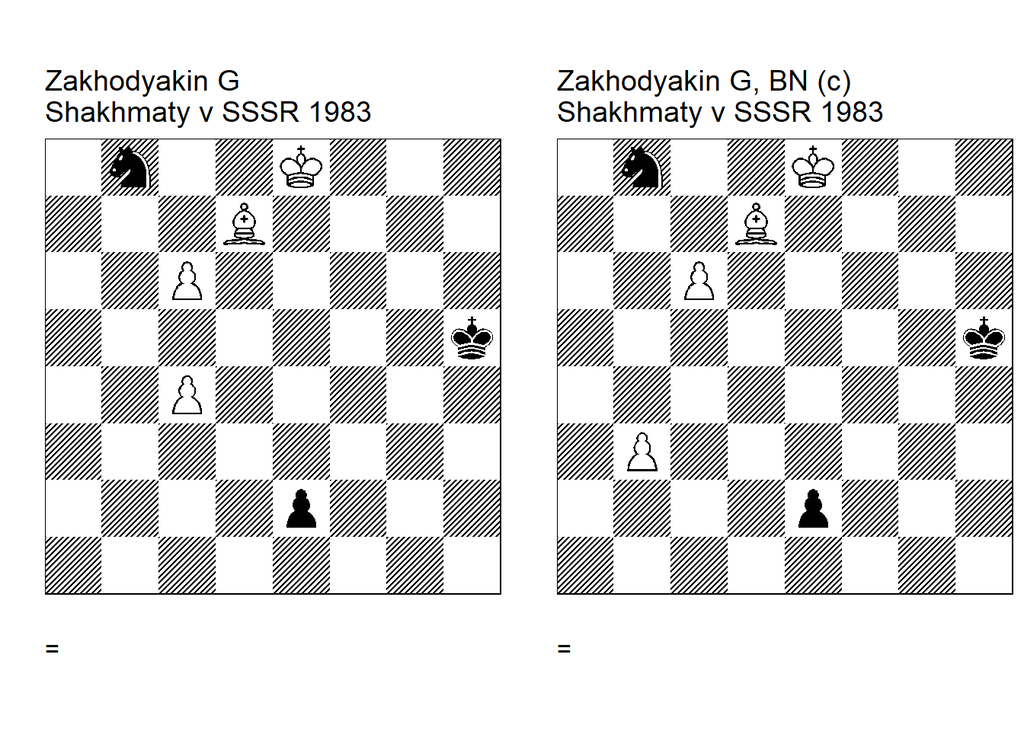

```
Zakhodyakin G
Shakhmaty v SSSR 1983
=0013.21e8h5 cook U3
1n2K3/3B4/2P5/7k/2P5/8/4p3/8 w - - 0 1
Shakhmaty v SSSR/3. U3: Bogdanov=I Shakhmaty v SSSR/12 1983. 1. Bg4+! Kxg4 2. c7 e1=Q+ 3.
Kf7 Qf1+ (3... Qf2+ 4. Kg8) 4. Kg7 Qa1+ (4... Nd7! <cook IB> 5. c8=Q Qf6+! 6. Kg8 (6. Kh7
Qe7+ 7. Kh6 Kf5 8. c5 (8. Qg8 Qh4+ 9. Kg7 Qf6+ 10. Kh7 Nf8+) 8... Qf7 9. Qc6 Qf8+ 10. Kh5
Qh8+ 11. Qh6 Nf6+) 6... Qe7 7. Kh8 Kf5! (7... Kg5? 8. Qa8 (8. c5? Nf6)  (8. Qg8+? Kh6)
8... Qf6+ (8... Nf6 9. Qg2+ Kh6 10. Qh2+ (10. Qh3+? Nh5!) 10... Kg6 11. Qg3+ Kf7 12.
Qg7+! ( 12. Qb8? Qd7!) ) 9. Kg8 Qg6+ 10. Kh8 Qh6+ 11. Kg8 Nf6+ 12. Kf7 Qg6+ 13. Ke6 Qf5+
14. Ke7! (14. Kd6? Ne4+ 15. Kc7 Qe5+ 16. Kb6 Qc5+ 17. Ka6 Qa3+ 18. Kb7 Nc5+ 19. Kb8 Nd7+
20. Kb7 Qf3+ 21. Ka7 Qf2+ 22. Kb7 Qg2+ 23. Ka7 Qa2+ 24. Kb7 Nc5+ 25. Kb8 Qh2+ 26. Ka7
Qc7+) 14... Qd7+ 15. Kf8 Qd6+ 16. Kf7 Qc7+ 17. Kf8)  8. c5 Kg5! 9. Qa8 Qf6+ 10. Kg8 Qg6+
11. Kh8 Qh6+ 12. Kg8 Nf6+ 13. Kf7 Qg6+ 14. Ke6 Qf5+ 15. Ke7 (15. Kd6 Ne4+! 16. Kc7 Qe5+
17. Kc8 Qe8+ 18. Kb7 Nxc5+ 19. Ka7 Qa4+ 20. Kb8 Qf4+ 21. Kc8 Qf8+) 15... Nd5+! 16. Kd6
Qf6+ 17. Kd7 Qe7+ 18. Kc6 Qe6+ 19. Kb7 Qd7+ 20. Ka6 Qa4+)  (4... Nd7)  (4... Qa1+) 5. Kg8
1/2-1/2.


Zakhodyakin G, BN (c)
Shakhmaty v SSSR 1983
=0013.21e8h5 (c)
1n2K3/3B4/2P5/7k/8/1P6/4p3/8 w - - 0 1
correction: Neuenschwander=B beatochess 15/04/2024. 1. Bg4+! Kxg4 2. c7 e1=Q+ 3. Kf7 Qf1+
(3... Qf2+ 4. Kg8) 4. Kg7 Qa1+ (4... Nd7 5. c8=Q Qf6+ 6. Kg8 Qe7 7. Qc4+) 5. Kg8 1/2-1/2.
```

### +0170.01e6h1 (1983). Correction

Date: 2024, April 15

File: Zakhodyakin1983c.pgn

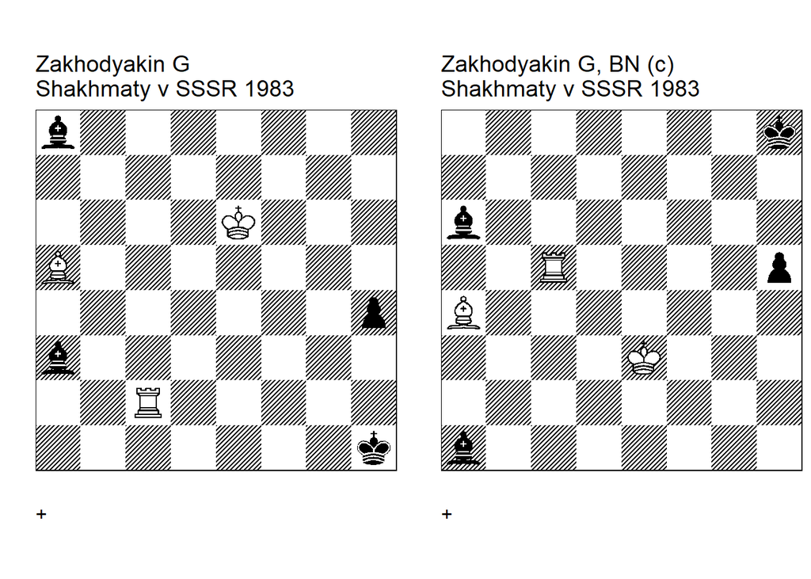

```
Zakhodyakin G
Shakhmaty v SSSR 1983
+0170.01e6h1 cook U3
b7/8/4K3/B7/7p/b7/2R5/7k w - - 0 1
Shakhmaty v SSSR/3. U3: Nikoronov=A Shakhmaty v SSSR/12 1983. 1. Rc3 Bb2 2. Rd3! Bg7
(2... Bg2 3. Bc7 Kg1 4. Rd1+ Bf1 5. Bb6+) 3. Rd1+ Kh2 (3... Kg2! <cook AN> 4. Rd8! Bf3 5.
Rg8 Bg4+! 6. Kd5 h3 7. Rxg7 h2 8. Rxg4+ Kh3) 4. Bc7+ Kh3 5. Rd3+ 1-0.


Zakhodyakin G, BN (c)
Shakhmaty v SSSR 1983
+0170.01e6h1 (c)
7k/8/b7/2R4p/B7/4K3/8/b7 w - - 0 1
correction: Neuenschwander=B beatochess 15/04/2024. 1. Rc6 (1. Rxh5+? Kg7!)  (1. Ra5?
Bc4!) 1... Bb7 (1... Bf1 2. Rc1) 2. Rd6! (2. Rb6? Bd5!) 2... Bg2 (2... Bg7 3. Rd8+ Kh7 4.
Bc2+ Kh6 5. Rd6+ Kg5 6. Rg6+) 3. Rd8+ Kh7 ( 3... Kg7 4. Rd1) 4. Bc2+ Kh6 5. Rd6+ 1-0.
```

Date: 2024, April 14

File: Zakhodyakin1986a.pgn

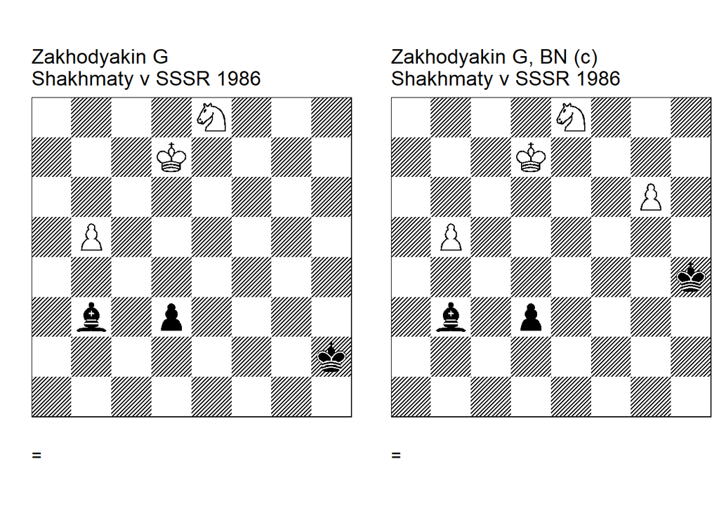

```
Zakhodyakin G
Shakhmaty v SSSR 1986
=0031.11d7h2 cook U3
4N3/3K4/8/1P6/8/1b1p4/7k/8 w - - 0 1
Shakhmaty v SSSR/6. U3: Bolshagin=V Shakhmaty v SSSR/11 1986. 1. Nf6! d2 ( 1... Ba4 2.
Kd6! Bxb5 3. Ne4! Kg2 4. Kc5) 2. Ng4+ Kg3 3. Ne3 Kf3 4. b6 Kxe3 5. b7 d1=Q+ 6. Ke7 Qd4
(6... Be6! <cook VB> 7. b8=Q Qd7+ 8. Kf6 Qf7+ 9. Kg5 (9. Ke5 Qf4+) 9... Qg7+ 10. Kh5 Bf7+
11. Kh4 Qh6+ 12. Kg3 (12. Kg4 Be6+ 13. Kg3 Qh3#) 12... Qg5+ 13. Kh3 Be6+ 14. Kh2 Qh4+ 15.
Kg2 Qf2+ 16. Kh1 Bd5#) 7. b8=Q 1/2-1/2.


Zakhodyakin G, BN (c)
Shakhmaty v SSSR 1986
=0031.21d7h2 (c)
4N3/3K4/6P1/1P6/7k/1b1p4/8/8 w - - 0 1
correction: Neuenschwander=B beatochess 14/04/2024. 1. Nd6 (1. Ng7? Kg4!) 1... d2 2. Nf5+
Kg4 3. Ne3+ Kf3 4. b6 Kxe3 5. b7 d1=Q+ 6. Ke7 1/2-1/2.
```

### +0160.10e4f1 (1983). Correction

Date: 2024, April 14

File: Zakhodyakin1983b.pgn

White dominates the black bishop after the somewhat paradoxical **4. Kd2** (moving the king away and giving Black more space). Unfortunately, **4. Rb2** also wins. The additional black pawn on f6 saves the study.

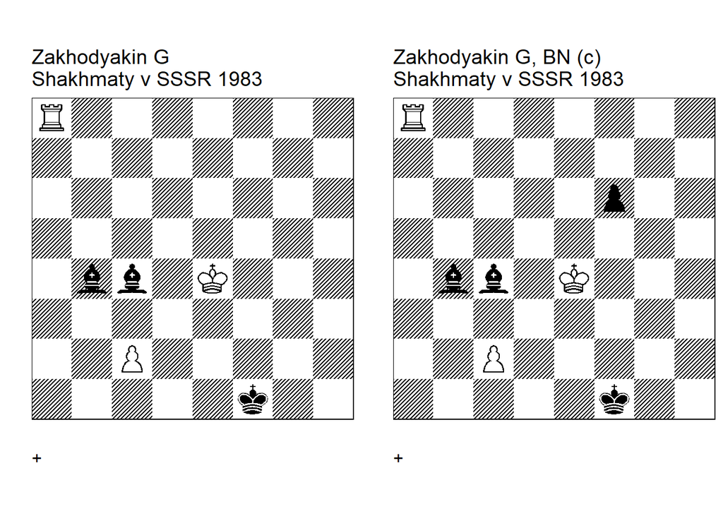

```
Zakhodyakin G
Shakhmaty v SSSR 1983
+0160.10e4f1 cook U2
R7/8/8/8/1bb1K3/8/2P5/5k2 w - - 0 1
Shakhmaty v SSSR/9. U2: Neuenschwander=B beatchess 14/04/2024. 1. Ra4 Bf7 2. Rxb4 Bg6+ 3.
Ke3 Bxc2 4. Kd2 (4. Rb2 <cook BN>  4... Bh7 5. Rf2+ Kg1 6. Kf3)  4... Bh7 5. Rh4 Bg8 6.
Rf4+ 1-0.


Zakhodyakin G, BN (c)
Shakhmaty v SSSR 1983
+0160.11e4f1 (c)
R7/8/5p2/8/1bb1K3/8/2P5/5k2 w - - 0 1
correction: Neuenschwander=B beatochess 14/04/2024. 1. Ra4 Bf7 (1... f5+ 2. Kd4!) 2. Rxb4
Bg6+ 3. Ke3 Bxc2 4. Kd2 (4. Rb2? Bd1! (4... Ba4 <or> ) 5. Rb1 Ke1 6. Kd3 f5) 4... Bh7 5.
Rh4 Bg8 6. Rf4+ 1-0.
```

### =3230.10a8b6 (1983). Correction

Date: 2024, April 13

File: Zakhodyakin1983a.pgn

In addition to Harold’s cook towards the end, there is also the unfortunate cook **1. Ra5**. The correction improves the study: rook not en prise in the starting position, quiet first move, and some White tries.

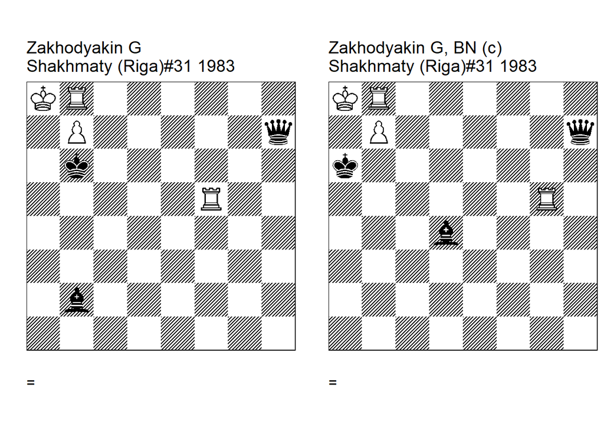

```
Zakhodyakin G
Shakhmaty (Riga)#31 1983
=3230.10a8b6 cook U2
KR6/1P5q/1k6/5R2/8/8/1b6/8 w - - 0 1
Shakhmaty (Riga)=21 Shakhmaty (Riga)/11. U2: Van_der_Heijden=H HHdbIV#51756 3-1-2010 U1:
Neuenschwander=B beatochess 13/04/2024. 1. Rb5+! (1. Ra5 <cook BN> ) 1... Kxb5 2. Rh8!
Qe4 3. Rh4! Qc6 4. Rh6 Qf3 5. Rh3 Qd5 6. Rh5 (6. Rb3+! <cook HH>  ) 6... Be5 7. Rxe5
1/2-1/2.


Zakhodyakin G, BN (c)
Shakhmaty (Riga)#31 1983
=3230.10a8b6 (c)
KR6/1P5q/k7/6R1/3b4/8/8/8 w - - 0 1
correction: Neuenschwander=B beatochess 13/04/2024. 1. Rb5! (1. Rg4? Qe7! 2. Rxd4 (2.
Rg6+ Bf6) 2... Qa3 3. Rd3 (3. Rg8 Kb6+ 4. Kb8 Qa7+ 5. Kc8 Qxb7+ 6. Kd8 Qb8+) 3... Qa5
(3... Qxd3? 4. Re8) 4. Rf8 Kb6+ 5. Kb8 Qa7+ 6. Kc8 Qxb7+ 7. Kd8 Qc7+ 8. Ke8 Qe5+ 9. Kd8
Qg5+ 10. Kc8 Qc5+ 11. Kd7 Qb5+)  (1. Rd5)  1... Kxb5 2. Rh8! (2. Re8 Qh1!) 2... Qe4 3.
Rh4 Qf3 4. Rh3! (4. Rxd4? Qa3+! 5. Kb8 Kb6) 4... Qc6 5. Rh6 Qg2 6. Rh2 Qd5 7. Rh5
1/2-1/2.
```

### =3101.01f3g7 (1982). Correction

Date: 2024, April 12

File: Zakhodyakin1982b.pgn

There are many ways to a draw in the original study. The way to draw in the correction is narrow, with a few tries in the slideslines. The study keeps the highlight **4. Rg6!**, but the end is a bit different.

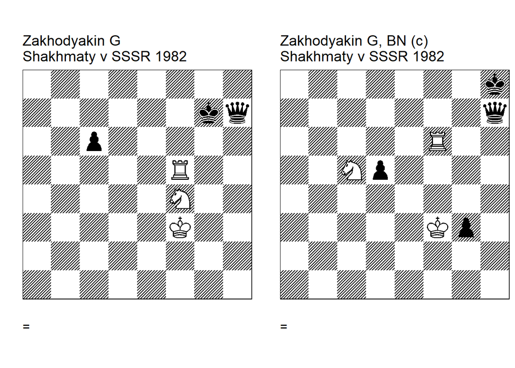

```
Zakhodyakin G
Shakhmaty v SSSR 1982
=3101.01f3g7 cook U2
8/6kq/2p5/5R2/5N2/5K2/8/8 w - - 0 1
Shakhmaty v SSSR/9. U2: Beasley=J HHdbIII#20150 3-2-2002. 1. Ne6+ Kh6 2. Rf6+ Kh5 3. Rg6!
Qd7 4. Nf4+ (4. Rg5+! <cook JB> 4... Kh4 5. Rg4+ Kh5 (5... Kh3? 6. Nf4+) 6. Rg5+) 4...
Kh4 5. Ng2+ 1/2-1/2.


Zakhodyakin G, BN (c)
Shakhmaty v SSSR 1982
=3101.02f3h8 (c)
7k/7q/5R2/2Np4/8/5Kp1/8/8 w - - 0 1
correction: Neuenschwander=B beatochess 12/04/2024. 1. Rf8+ Kg7 2. Ne6+ Kh6 ( 2... Kg6 3.
Kxg3! (3. Nf4+? Kg5 4. Kxg3 Qh4+ 5. Kg2 (5. Kf3 Qh1+) 5... Qg4+ 6. Kf2 Qxf4+) 3... Qe7 4.
Nf4+ Kg5 (4... Kg7 5. Rd8)  (4... Kh7 5. Rh8+ Kg7 6. Rd8) 5. Nh3+ and Rf3 ) 3. Rf6+ (3.
Kxg3 Qg6+)  (3. Nf4 Qg7)  (3. Rf4 Qd3+)  3... Kh5 4. Rg6! (4. Nf4+ Kg5 (4... Kh4? 5. Rg6)
5. Rg6+ Kf5 6. Rxg3 Qh1+ is theoreatically lost ) 4... Qf7+ (4... Qxg6 5. Nf4+ Kg5 6.
Nxg6 Kxg6 7. Kxg3) 5. Nf4+ Qxf4+ 6. Kxf4 Kxg6 7. Kxg3 1/2-1/2.
```

### =0040.12b3e4 (1982). Cook, correction

Date: 2024, April 12

File: Zakhodyakin1982a.pgn

Keith’s correction is incorrect due to **1… Bd3!** or **1… Bg2!**. The correction has a more natural starting position.

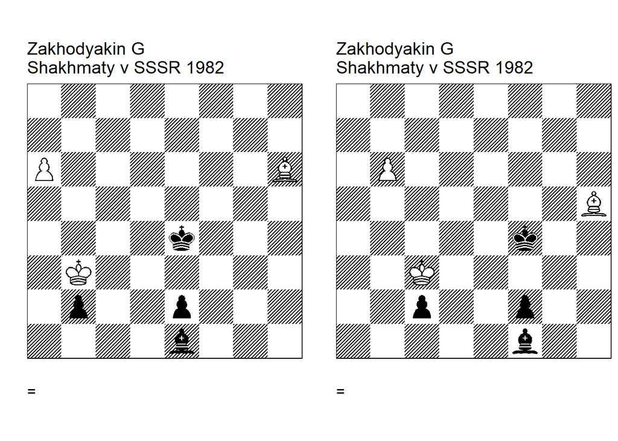

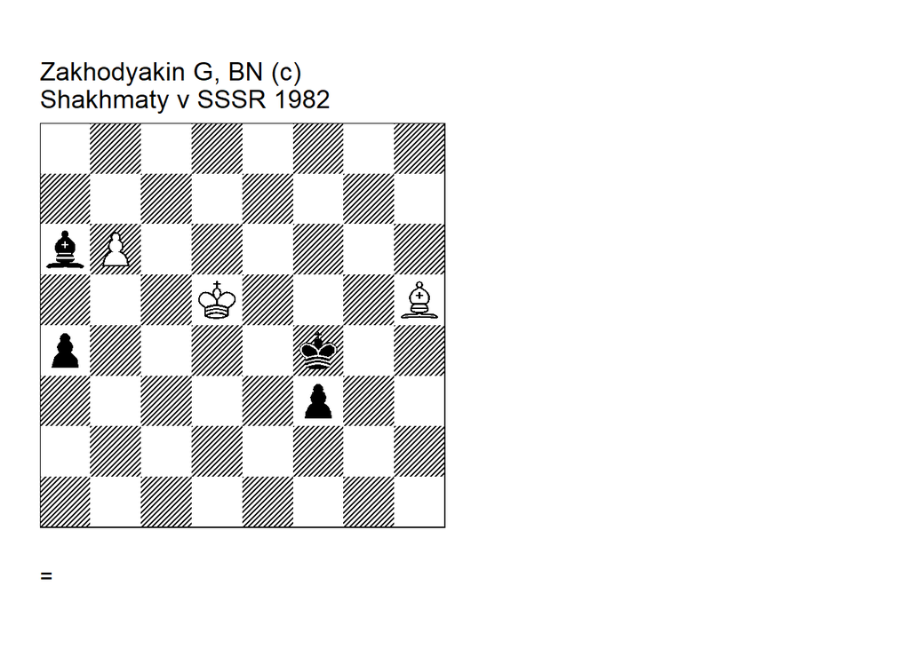

```
Zakhodyakin G
Shakhmaty v SSSR 1982
=0040.12b3e4 cook U3
8/8/P6B/8/4k3/1K6/1p2p3/4b3 w - - 0 1
Shakhmaty v SSSR/12. U3: Isakov=V Shakhmaty v SSSR/2 1985 U3: Haworth=G Bleicher=E
HHdbIV#50746 1-11-2009. 1. Kc2 (1. Kxb2? Bc3+)  (1. Ka2? Kd3 2. a7 Kc2) 1... Ba5! 2. Bd2!
(2. a7? b1=Q+ 3. Kxb1 e1=Q+ 4. Bc1 Qb4+) 2... Bxd2 3. a7 b1=Q+ (3... Kd4! <cook VI> ) 4.
Kxb1 e1=Q+ 5. Ka2 Qc1 (5... Kd4! <cook VI> 6. a8=Q Qe6+)  (5... Kd3! <cook GH/EB> ) 6.
a8=Q+ 1/2-1/2.


Zakhodyakin G
Shakhmaty v SSSR 1982
=0040.12c3f4 cook (c)
8/8/1P6/7B/5k2/2K5/2p2p2/5b2 w - - 0 1
Shakhmaty v SSSR/12. correction: Keith=D EG=188 4/2012. U3 Neuenschwander=B beatochess
12/04/2024. 1. Kd2 Ba6 (1... Bd3 <cook BN> 2. Be2 (2. b7 f1=Q 3. b8=Q+ Kg5 4. Qe5+ Kh6)
2... c1=Q+ 3. Kxc1 Ke3! 4. b7 Kxe2)  (1... Bg2 <cook BN> 2. Be2 Be4) 2. Be2 Bxe2 3. b7
c1=Q+ 4. Kxc1 f1=Q+ 5. Kb2 Qd1 6. b8=Q+ 1/2-1/2.
```

```
Zakhodyakin G, BN (c)
Shakhmaty v SSSR 1982
=0040.12d5f4 (c)
8/8/bP6/3K3B/p4k2/5p2/8/8 w - - 0 1
correction: Neuenschwander=B beatochess 12/04/2024. 1. Kd4! (1. Bxf3! a3) 1... f2 2. Be2!
a3 (2... Bxe2 3. b7 f1=Q 4. b8=Q+ = , e.g. 4... Kg4 5. Qg8+ Kh4 6. Qh7+ Kg3 7. Qg6+ Bg4
8. Qd3+) 3. Kc3 a2 4. Kb2 Bxe2 5. b7 a1=Q+ 6. Kxa1 f1=Q+ 7. Kb2 1/2-1/2.
```

Date: 2024, April 11

File: Zakhodyakin1981a.pgn

With the white rook on c2 the study is correct.

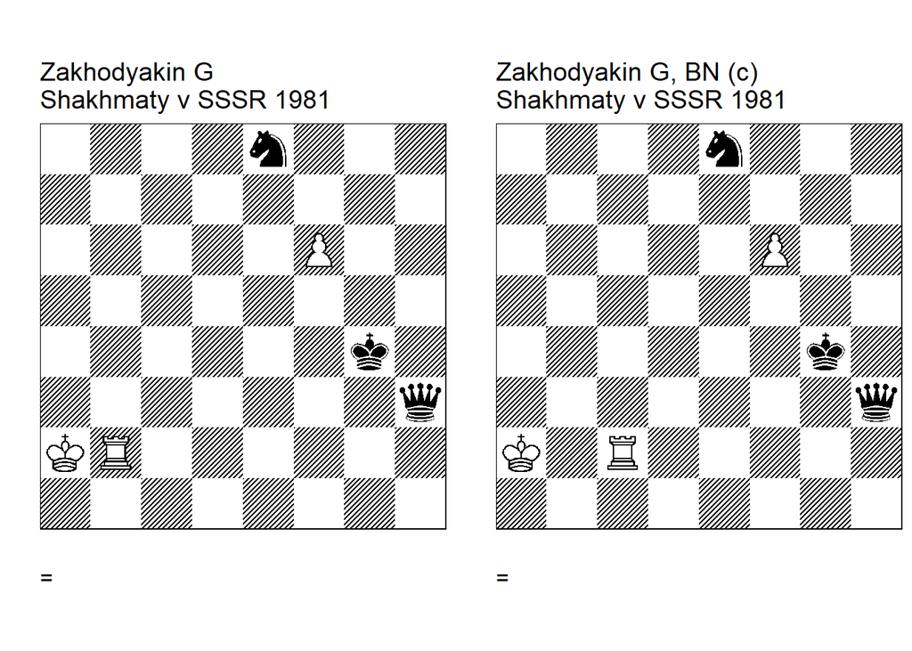

```
Zakhodyakin G
Shakhmaty v SSSR 1981
=3103.10a2g4 cook U2
4n3/8/5P2/8/6k1/7q/KR6/8 w - - 0 1
Shakhmaty v SSSR/1. U2: Beasley=J HHdbIII#21035 3-2-2002. 1. f7 Qh8 2. Rg2+! (2. Rf2?
Nf6)  (2. Rb8 Qh2+ 3. Ka3 Qd6+ 4. Ka4 (4. Rb4+! <cook JB> )  4... Qd7+) 2... Kf3 3. Rg8!
Qh2+ 4. Rg2! Qh8 5. Rg8 Qh2+ 6. Rg2 Qxg2+ 7. Ka3 1/2-1/2.


Zakhodyakin G, BN (c)
Shakhmaty v SSSR 1981
=3103.10a2g4 (c)
4n3/8/5P2/8/6k1/7q/K1R5/8 w - - 0 1
Shakhmaty v SSSR/1. correction: Neuenschwander=B beatochess 11/04/2024 . 1. f7 Qh8 2.
Rg2+ (2. Rc8? Qh2+ 3. Kb3 Qg3+ 4. Rc3 (4. Kb4 Qd6+) 4... Qb8+ 5. Kc2 Nd6) 2... Kf3 3.
Rg8! Qh2+ 4. Rg2! Qh8 5. Rg8 Qh2+ 6. Rg2 Qxg2+ 7. Ka3 1/2-1/2.
```

### =3041.10g8h3 (1980). Modification

Date: 2024, April 11

File: Zakhodyakin1980b.pgn

The modification shows the idea of the original study with a different material constellation.

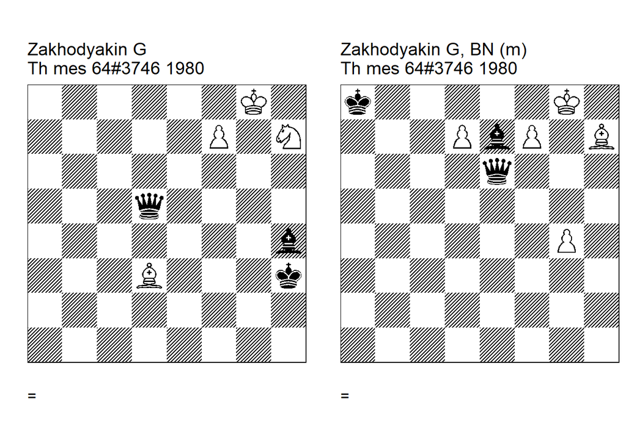

```
Zakhodyakin G
Th mes 64#3746 1980
=3041.10g8h3 cook U3
6K1/5P1N/8/3q4/7b/3B3k/8/8 w - - 0 1
Th mes 64=100 Th mes 64/10-12. U3: Pachman=V Th mes 64=103 8-9/1981 U3: Beasley=J
HHdbIII#22304 3-2-2002. 1. Bf5+! (1. Be4? Qa2 2. Bb1 Qg2+ 3. Kf8 Be1 4. Ke8 Bb4) 1... Kh2
2. Ng5! Bxg5 3. Be4! Qa2 (3... Qb3! <cook JB>  4. Bc2 Qg3 5. f8=Q Bh6+) 4. Bb1 Qg2! <cook
VP> 5. Be4 Qg3 1/2-1/2.


Zakhodyakin G, BN (m)
Th mes 64#3746 1980
=3040.30g8a8 (m)
k5K1/3PbP1B/4q3/8/6P1/8/8/8 w - - 0 1
modification: Neuenschwander=B beatochess 11/04/2024. 1. d8=Q+ (1. g5? Qxd7 )  (1. Bf5?
Qd6) 1... Bxd8 2. Bf5 (2. g5? Be7 3. g6 Qc8+ 4. Kg7 Qf8#) 2... Qc4 3. g5 (3. Bd3? Qxg4+)
3... Bxg5 4. Bd3 Qa2 (4... Qd5 5. Be4) 5. Bb1 Qb3 6. Bc2 Qe6 7. Bf5 1/2-1/2.
```